# Serum brain-derived tau distinguishes acute neurotrauma diagnoses

2026-07-01

```r
rm(list = ls())
gc()
```

```
##           used (Mb) gc trigger  (Mb) limit (Mb) max used  (Mb)
## Ncells 1355793 72.5    2569867 137.3         NA  2569867 137.3
## Vcells 2361369 18.1    8388608  64.0      65536  3708899  28.3
```

```r
library(readxl)
library(data.table)
library(openxlsx)
library(stringr)
library(tidyr)
library(dplyr)
library(gtsummary)
library(cardx)
library(ggplot2)
library(ggstatsplot)
library(ggsignif)
library(ggpubr)
library(ggExtra)
library(patchwork)
library(e1071)
library(lmerTest)
library(knitr)
library(purrr)
```

```r
load("~/Desktop/Projects/2025_05_19_TBI_SCI_BDTau/Processed_Data/tbi_sci_cntr_cleaned.RData")

# matched baseline

intersect_vars <- Reduce(intersect, list(
  names(sci_match_demo_BL_cleaned),
  names(tbi_match_demo_BL_cleaned)
))

match_baseline_cleaned <- rbindlist(
  list(
    sci_match_demo_BL_cleaned %>% dplyr::select(all_of(intersect_vars)),
    tbi_match_demo_BL_cleaned %>% dplyr::select(all_of(intersect_vars))
  ),
  use.names = TRUE,
  fill = FALSE
) %>%
  mutate(Cohort = factor(Cohort, levels = c("SCI", "Moderate TBI", "Severe TBI"))) %>%
  mutate(Cohort2 = factor(case_when(Cohort %in% c("SCI") ~ Cohort,
                                    TRUE ~ "TBI"),
                          levels = c("SCI","TBI")))
```

```r
# Extended table 1

extended_table1 <- serum_baseline_cleaned %>%
  dplyr::select(Age, Sex, mean_serum_BDTau, Cohort2) %>%
  tbl_summary(
    by = Cohort2,
    type = list(all_continuous() ~ "continuous2"),
    statistic = list(
      all_continuous() ~ c("{mean} ({sd})", "{median} ({p25}, {p75})"),
      all_categorical() ~ "{n} ({p}%)"
    ),
    digits = list(
      all_continuous() ~ 1,
      all_categorical() ~ c(0, 1)
    ),
    missing = "ifany",
    missing_text = "(Missing)",
    label = list(Age ~ "Age (years)",
                 Sex ~ "Sex",
                 mean_serum_BDTau ~ "BD-Tau (pg/mL)")
  ) %>%
  modify_header(label ~ "**Variable**") %>%
  add_overall() %>%
  add_p() %>%
  bold_labels()

extended_table1
```

| **Variable** | **Overall** N = 364<sup>1</sup> | **Control** N = 22<sup>1</sup> | **SCI** N = 57<sup>1</sup> | **TBI** N = 285<sup>1</sup> | **p-value**<sup>2</sup> |
| --- | --- | --- | --- | --- | --- |
| Age (years) |  |  |  |  | 0.003 |
| Mean (SD) | 43.6 (19.2) | 43.4 (15.6) | 52.0 (20.4) | 42.0 (18.9) |  |
| Median (Q1, Q3) | 41.0 (26.0, 61.0) | 44.0 (30.0, 58.0) | 54.0 (34.0, 68.0) | 38.0 (25.0, 58.0) |  |
| Sex |  |  |  |  | 0.014 |
| Female | 88 (24.2%) | 11 (50.0%) | 12 (21.1%) | 65 (22.8%) |  |
| Male | 276 (75.8%) | 11 (50.0%) | 45 (78.9%) | 220 (77.2%) |  |
| BD-Tau (pg/mL) |  |  |  |  | <0.001 |
| Mean (SD) | 137.0 (232.7) | 5.7 (1.7) | 29.5 (45.2) | 168.6 (253.3) |  |
| Median (Q1, Q3) | 61.7 (28.0, 164.7) | 5.3 (4.2, 6.7) | 15.5 (10.1, 28.2) | 93.7 (48.2, 195.5) |  |

<sup>1</sup> n (%)  
<sup>2</sup> Kruskal-Wallis rank sum test; Pearson’s Chi-squared test

```r
# Extended table 2

extended_table2 <- csf_baseline_cleaned %>%
  dplyr::select(Age, Sex, mean_csf_BDTau, Cohort2) %>%
  tbl_summary(
    by = Cohort2,
    type = list(all_continuous() ~ "continuous2"),
    statistic = list(
      all_continuous() ~ c("{mean} ({sd})", "{median} ({p25}, {p75})"),
      all_categorical() ~ "{n} ({p}%)"
    ),
    digits = list(
      all_continuous() ~ 1,
      all_categorical() ~ c(0, 1)
    ),
    missing = "ifany",
    missing_text = "(Missing)",
    label = list(Age ~ "Age (years)",
                 Sex ~ "Sex",
                 mean_csf_BDTau ~ "BD-Tau (pg/mL)")
  ) %>%
  modify_header(label ~ "**Variable**") %>%
  add_overall() %>%
  add_p() %>%
  bold_labels()

extended_table2
```

| **Variable** | **Overall** N = 261<sup>1</sup> | **SCI** N = 32<sup>1</sup> | **TBI** N = 229<sup>1</sup> | **p-value**<sup>2</sup> |
| --- | --- | --- | --- | --- |
| Age (years) |  |  |  | 0.001 |
| Mean (SD) | 43.2 (18.9) | 53.4 (18.6) | 41.8 (18.5) |  |
| Median (Q1, Q3) | 40.0 (26.0, 60.0) | 55.5 (36.0, 67.5) | 39.0 (25.0, 58.0) |  |
| Sex |  |  |  | 0.4 |
| Female | 57 (21.8%) | 9 (28.1%) | 48 (21.0%) |  |
| Male | 204 (78.2%) | 23 (71.9%) | 181 (79.0%) |  |
| BD-Tau (pg/mL) |  |  |  | <0.001 |
| Mean (SD) | 6,735.8 (11,837.7) | 1,687.5 (1,968.7) | 7,441.2 (12,457.8) |  |
| Median (Q1, Q3) | 3,271.7 (1,410.4, 7,878.9) | 1,049.7 (383.2, 2,649.8) | 3,764.1 (1,896.5, 8,360.0) |  |

<sup>1</sup> n (%)  
<sup>2</sup> Wilcoxon rank sum test; Pearson’s Chi-squared test

```r
# Extended table 3

extended_table3 <- match_baseline_cleaned %>%
  dplyr::select(Age, Sex, mean_serum_BDTau, mean_csf_BDTau, mean_BDTau_Ratio, mean_Hour_Diff, Cohort) %>%
  tbl_summary(
    by = Cohort,
    type = list(all_continuous() ~ "continuous2"),
    statistic = list(
      all_continuous() ~ c("{mean} ({sd})", "{median} ({p25}, {p75})"),
      all_categorical() ~ "{n} ({p}%)"
    ),
    digits = list(
      all_continuous() ~ 2,
      all_categorical() ~ c(0, 1)
    ),
    missing = "ifany",
    missing_text = "(Missing)",
    label = list(Age ~ "Age (years)",
                 Sex ~ "Sex",
                 mean_serum_BDTau ~ "serum BD-Tau (pg/mL)",
                 mean_csf_BDTau ~ "csf BD-Tau (pg/mL)",
                 mean_BDTau_Ratio ~ "serum/csf BD-Tau ratio")
  ) %>%
  modify_header(label ~ "**Variable**") %>%
  add_overall() %>%
  add_p() %>%
  bold_labels()

extended_table3
```

| **Variable** | **Overall** N = 258<sup>1</sup> | **SCI** N = 30<sup>1</sup> | **Moderate TBI** N = 2<sup>1</sup> | **Severe TBI** N = 226<sup>1</sup> | **p-value**<sup>2</sup> |
| --- | --- | --- | --- | --- | --- |
| Age (years) |  |  |  |  | 0.010 |
| Mean (SD) | 43.01 (18.88) | 52.50 (18.80) | 30.00 (7.07) | 41.87 (18.62) |  |
| Median (Q1, Q3) | 40.00 (26.00, 59.00) | 54.00 (36.00, 65.00) | 30.00 (25.00, 35.00) | 39.00 (25.00, 58.00) |  |
| Sex |  |  |  |  | 0.036 |
| Female | 59 (22.9%) | 9 (30.0%) | 2 (100.0%) | 48 (21.2%) |  |
| Male | 199 (77.1%) | 21 (70.0%) | 0 (0.0%) | 178 (78.8%) |  |
| serum BD-Tau (pg/mL) |  |  |  |  | <0.001 |
| Mean (SD) | 161.69 (420.72) | 25.39 (30.54) | 37.06 (7.50) | 180.88 (446.18) |  |
| Median (Q1, Q3) | 70.37 (39.92, 164.01) | 15.11 (10.06, 28.25) | 37.06 (31.75, 42.36) | 81.99 (49.56, 182.34) |  |
| csf BD-Tau (pg/mL) |  |  |  |  | <0.001 |
| Mean (SD) | 6,195.21 (8,897.07) | 1,759.71 (2,013.76) | 617.75 (573.09) | 6,833.35 (9,305.00) |  |
| Median (Q1, Q3) | 3,259.03 (1,520.06, 7,564.15) | 1,133.31 (313.20, 2,845.89) | 617.75 (212.51, 1,022.99) | 3,867.93 (1,810.04, 8,251.75) |  |
| serum/csf BD-Tau ratio |  |  |  |  | 0.2 |
| Mean (SD) | 0.12 (0.92) | 0.04 (0.05) | 0.10 (0.08) | 0.14 (0.98) |  |
| Median (Q1, Q3) | 0.02 (0.01, 0.06) | 0.02 (0.01, 0.06) | 0.10 (0.04, 0.15) | 0.02 (0.01, 0.06) |  |
| mean_Hour_Diff |  |  |  |  | <0.001 |
| Mean (SD) | 2.69 (2.96) | 0.37 (1.34) | 4.92 (1.19) | 2.98 (2.99) |  |
| Median (Q1, Q3) | 1.68 (0.00, 4.08) | 0.00 (0.00, 0.00) | 4.92 (4.08, 5.76) | 2.16 (0.24, 4.80) |  |

<sup>1</sup> n (%)  
<sup>2</sup> Kruskal-Wallis rank sum test; Fisher’s exact test

```r
library(rstatix)
library(ggpubr)
library(gt)
library(knitr)
library(kableExtra)

integrated_color_palette <- c(
  "Control" = "grey50",
  "A SCI" = "#007382",
  "B SCI" = "#019787",
  "C/D SCI" = "#82e1cd",
  "Mild TBI" = "#f8dda4",
  "Moderate TBI" = "#f9a03f",
  "Severe TBI" = "#d45113"
)

cntr_tbi_color_palette <- c(
  "Control" = "grey50",
  "Moderate TBI" = "#f9a03f",
  "Severe TBI" = "#d45113"
  )

cntr_sci_color_palette <- c(
  "Control" = "grey50",
  "A SCI" = "#007382",
  "B SCI" = "#019787",
  "C/D SCI" = "#82e1cd"
  )

integrated_3color_palette <- c(
  "Control" = "grey50",
  "SCI" = "#07668d",
  "TBI" = "#813405"
)

asia_a_ids <- sci_serum_demo_BL_cleaned[!is.na(sci_serum_demo_BL_cleaned$ASIA) & sci_serum_demo_BL_cleaned$ASIA == "A", ]$Subject.ID
asia_b_ids <- sci_serum_demo_BL_cleaned[!is.na(sci_serum_demo_BL_cleaned$ASIA) & sci_serum_demo_BL_cleaned$ASIA == "B", ]$Subject.ID
asia_cd_ids <- sci_serum_demo_BL_cleaned[!is.na(sci_serum_demo_BL_cleaned$ASIA) & sci_serum_demo_BL_cleaned$ASIA %in% c("C","D"), ]$Subject.ID

serum_df <- serum_baseline_cleaned %>%
  filter(Cohort %in% c("Control","SCI","Mild TBI","Moderate TBI","Severe TBI")) %>%
  filter(!is.na(Cohort2), !is.na(mean_serum_log2_BDTau)) %>%
  mutate(
    Cohort2 = factor(Cohort2, levels = names(integrated_3color_palette))) %>%
  mutate(
    Cohort3 = case_when(
      Cohort2 == "SCI" & !is.na(Subject.ID) & Subject.ID %in% asia_a_ids  ~ "A SCI",
      Cohort2 == "SCI" & !is.na(Subject.ID) & Subject.ID %in% asia_b_ids  ~ "B SCI",
      Cohort2 == "SCI" & !is.na(Subject.ID) & Subject.ID %in% asia_cd_ids ~ "C/D SCI",
      TRUE ~ as.character(Cohort)
    ),
    Cohort3 = factor(
      Cohort3,
      levels = c("Control", "C/D SCI", "B SCI", "A SCI", "Mild TBI", "Moderate TBI", "Severe TBI")
    )
  )

# ==================================================
# General Control/SCI/TBI
# ==================================================

# get summary by cohort

serum_summary_by_cohort <- serum_df %>%
  group_by(Cohort2) %>%
  summarise(
    n = n(),
    mean_BDTau = mean(mean_serum_BDTau, na.rm = TRUE),
    sd_BDTau = sd(mean_serum_BDTau, na.rm = TRUE),
    median_BDTau = median(mean_serum_BDTau, na.rm = TRUE),
    p25_BDTau = quantile(mean_serum_BDTau, 0.25, na.rm = TRUE),
    p75_BDTau = quantile(mean_serum_BDTau, 0.75, na.rm = TRUE),
    min_BDTau = min(mean_serum_BDTau, na.rm = TRUE),
    max_BDTau = max(mean_serum_BDTau, na.rm = TRUE)
  )

fc_tbi_sci <- serum_summary_by_cohort$median_BDTau[serum_summary_by_cohort$Cohort2 == "TBI"] /
              serum_summary_by_cohort$median_BDTau[serum_summary_by_cohort$Cohort2 == "SCI"]

fc_tbi_sci
```

```
## [1] 6.035823
```

```r
fc_tbi_cntr <- serum_summary_by_cohort$median_BDTau[serum_summary_by_cohort$Cohort2 == "TBI"] /
              serum_summary_by_cohort$median_BDTau[serum_summary_by_cohort$Cohort2 == "Control"]

fc_tbi_cntr
```

```
## [1] 17.71403
```

```r
fc_sci_cntr <- serum_summary_by_cohort$median_BDTau[serum_summary_by_cohort$Cohort2 == "SCI"] /
              serum_summary_by_cohort$median_BDTau[serum_summary_by_cohort$Cohort2 == "Control"]

fc_sci_cntr
```

```
## [1] 2.934816
```

```r
# comparison

kw_res <- serum_df %>% kruskal_test(mean_serum_log2_BDTau ~ Cohort2)

H <- unname(kw_res[["statistic"]])
df <- unname(kw_res[["df"]])
p <- unname(kw_res[["p"]])

H; df; p
```

```
## [1] 134.4393
```

```
## [1] 2
```

```
## [1] 6.41e-30
```

```r
dunn_res <- serum_df %>%
  dunn_test(mean_serum_log2_BDTau ~ Cohort2, p.adjust.method = "BH") %>%
  mutate(
    p.adj.sci = format(p.adj, scientific = TRUE, digits = 3)
  ) %>%
  add_significance("p.adj") %>%
  arrange(group1, group2)

dunn_report <- dunn_res %>%
  dplyr::select(group1, group2, statistic, p, p.adj) %>%
  dplyr::mutate(
    z = statistic,
    p_raw = formatC(p, format = "e", digits = 2),
    p_bonf = formatC(p.adj, format = "e", digits = 2)
  ) %>%
  dplyr::select(group1, group2, z, p_raw, p_bonf)

dunn_report
```

```
## # A tibble: 3 × 5
##   group1  group2     z p_raw    p_bonf
##   <chr>   <chr>  <dbl> <chr>    <chr>
## 1 Control SCI     2.58 9.86e-03 9.86e-03
## 2 Control TBI     8.61 7.46e-18 1.12e-17
## 3 SCI     TBI     8.66 4.61e-18 1.12e-17
```

```r
y_max <- max(serum_df$mean_serum_log2_BDTau, na.rm = TRUE)
step  <- 0.04 * y_max
dunn_res <- dunn_res %>%
  mutate(y.position = y_max + row_number() * step)

p_serum <- ggplot(serum_df, aes(x = Cohort2, y = mean_serum_log2_BDTau, fill = Cohort2, color = Cohort2)) +
  geom_boxplot(width = 0.62, alpha = 0.6, outlier.shape = 3, outlier.color = "red", color = "black") +
  geom_jitter(width = 0.15, size = 1.2, shape = 1, alpha = 0.65, show.legend = FALSE) +
  # median "tick"
  stat_summary(fun = median, geom = "crossbar", width = 0.5, size = 0.45, color = "black") +
  # palettes
  scale_fill_manual(values = integrated_3color_palette, guide = "none") +
  scale_color_manual(values = integrated_3color_palette, guide = "none") +
  labs(x = NULL, y = "log2(BD-Tau)", title = NULL) +
  theme_classic(base_size = 12) +
  theme(
    axis.text.x = element_text(angle = 45, hjust = 1, vjust = 1),
    plot.title = element_text(face = "bold", size = 13)
  ) +
  # pairwise p-values (stars); hide non-sig if you want
  ggpubr::stat_pvalue_manual(
    dunn_res,
    label = "p.adj.signif",
    xmin = "group1",
    xmax = "group2",
    y.position = "y.position",
    tip.length = 0.01,
    step.increase = 0.0,
    bracket.size = 0.4,
    size = 6,
    hide.ns = TRUE
  ) +
  # Omnibus p-value annotation at the top-right
  annotate(
    "text",
    x = Inf, y = max(dunn_res$y.position, na.rm = TRUE) + 0.8 * step,
    label = paste0("Kruskal-Wallis p = ", signif(kw_res$p, 3)),
    hjust = 1, vjust = 0, size = 3.6
  ) +
  ylim(1,12.5)

dunn_res %>%
  mutate(
    p_formatted = ifelse(p < 0.001,
                        format(p, scientific = TRUE, digits = 2),
                        sprintf("%.3f", p)),
    p.adj_formatted = ifelse(p.adj < 0.001,
                            format(p.adj, scientific = TRUE, digits = 2),
                            sprintf("%.3f", p.adj))
  ) %>%
  select(group1, group2, n1, n2, statistic, p_formatted, p.adj_formatted, p.adj.signif) %>%
  kable(
    col.names = c("Group 1", "Group 2", "N1", "N2", "Statistic", "P-value", "Adjusted P", "Sig."),
    caption = "Pairwise Dunn's Test Results for Serum BD-Tau (log2) by Cohort",
    align = c('l', 'l', 'c', 'c', 'c', 'c', 'c', 'c')
  ) %>%
  kable_styling(
    bootstrap_options = c("striped", "hover", "condensed"),
    full_width = FALSE,
    position = "left"
  )
```

Pairwise Dunn’s Test Results for Serum BD-Tau (log2) by Cohort

| Group 1 | Group 2 | N1 | N2 | Statistic | P-value | Adjusted P | Sig. |
| --- | --- | --- | --- | --- | --- | --- | --- |
| Control | SCI | 22 | 57 | 2.580865 | 0.010 | 0.010 | ** |
| Control | TBI | 22 | 285 | 8.607668 | 7.5e-18 | 1.1e-17 | **** |
| SCI | TBI | 57 | 285 | 8.662527 | 4.6e-18 | 1.1e-17 | **** |

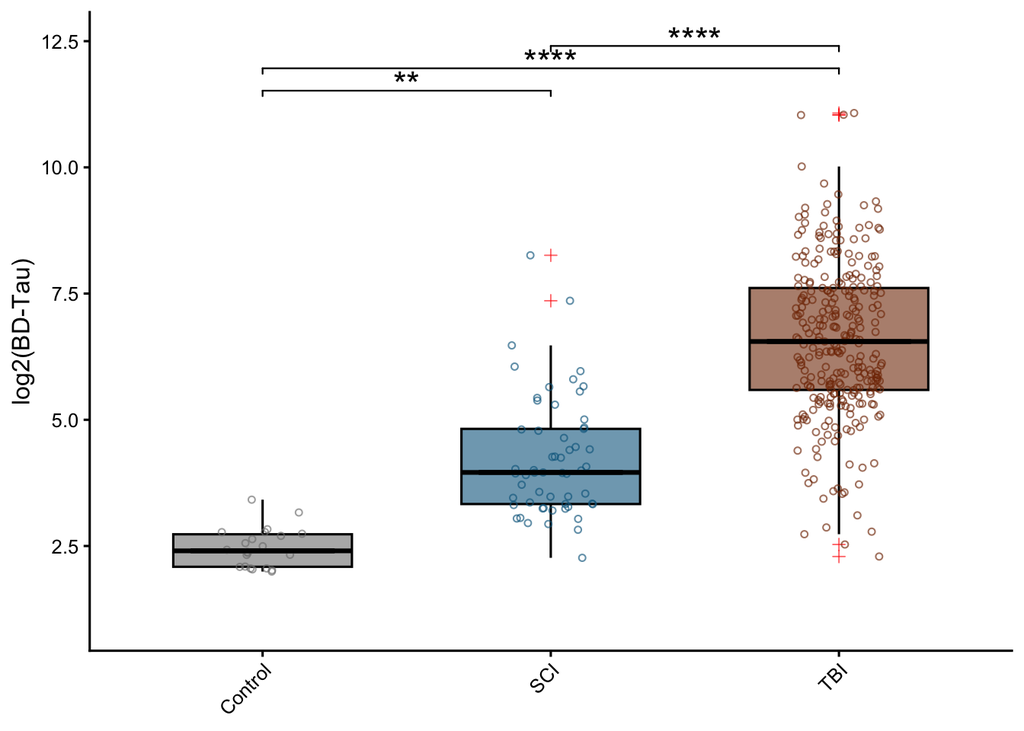

```
#> p_bd_zoom <- p_bd +
#>   ggforce::facet_zoom(y = mean_serum_log2_BDTau <= 50) +
#>   labs(subtitle = "Zoomed-in view for BD-Tau ≤ 50 pg/mL") +
#>   theme(
#>     panel.border = element_rect(color = "black", linewidth = 0.5)
#>     # strip.background = element_blank()
#>   )
```

```r
p_serum # FIGURE 1A
```

```r
# ==================================================
# Detailed Control/SCI/TBI
# ==================================================

# get summary by cohort
serum_df <- serum_df %>%
  filter(!is.na(Cohort3))

summary_by_cohort <- serum_df %>%
  group_by(Cohort3) %>%
  summarise(
    n = n(),
    mean_BDTau = mean(mean_serum_BDTau, na.rm = TRUE),
    sd_BDTau = sd(mean_serum_BDTau, na.rm = TRUE),
    median_BDTau = median(mean_serum_BDTau, na.rm = TRUE),
    p25_BDTau = quantile(mean_serum_BDTau, 0.25, na.rm = TRUE),
    p75_BDTau = quantile(mean_serum_BDTau, 0.75, na.rm = TRUE),
    min_BDTau = min(mean_serum_BDTau, na.rm = TRUE),
    max_BDTau = max(mean_serum_BDTau, na.rm = TRUE)
  )

# comparison

kw_res <- serum_df %>% kruskal_test(mean_serum_log2_BDTau ~ Cohort3)
H <- unname(kw_res[["statistic"]])
df <- unname(kw_res[["df"]])
p <- unname(kw_res[["p"]])

H; df; p
```

```
## [1] 161.7804
```

```
## [1] 6
```

```
## [1] 2.49e-32
```

```r
dunn_res <- serum_df %>%
  dunn_test(mean_serum_log2_BDTau ~ Cohort3, p.adjust.method = "BH") %>%
  mutate(
    p.adj.sci = format(p.adj, scientific = TRUE, digits = 3)
  ) %>%
  add_significance("p.adj") %>%
  arrange(group1, group2)

dunn_report <- dunn_res %>%
  dplyr::select(group1, group2, statistic, p, p.adj) %>%
  dplyr::mutate(
    z = statistic,
    p_raw = formatC(p, format = "e", digits = 2),
    p_bonf = formatC(p.adj, format = "e", digits = 2)
  ) %>%
  dplyr::select(group1, group2, z, p_raw, p_bonf)

dunn_report
```

```
## # A tibble: 21 × 5
##    group1  group2            z p_raw    p_bonf
##    <chr>   <chr>         <dbl> <chr>    <chr>
##  1 A SCI   Mild TBI     -1.13  2.60e-01 4.19e-01
##  2 A SCI   Moderate TBI  2.23  2.60e-02 4.96e-02
##  3 A SCI   Severe TBI    5.74  9.74e-09 6.82e-08
##  4 B SCI   A SCI         0.622 5.34e-01 6.42e-01
##  5 B SCI   Mild TBI     -0.283 7.77e-01 7.77e-01
##  6 B SCI   Moderate TBI  2.33  1.99e-02 4.64e-02
##  7 B SCI   Severe TBI    4.03  5.64e-05 2.37e-04
##  8 C/D SCI A SCI         0.435 6.63e-01 7.33e-01
##  9 C/D SCI B SCI        -0.309 7.58e-01 7.77e-01
## 10 C/D SCI Mild TBI     -0.740 4.59e-01 6.03e-01
## # ℹ 11 more rows
```

```r
y_max <- max(serum_df$mean_serum_log2_BDTau, na.rm = TRUE)
step  <- 0.04 * y_max
dunn_res <- dunn_res %>%
  mutate(y.position = y_max + row_number() * step)

p_serum_detail <- ggplot(serum_df, aes(x = Cohort3, y = mean_serum_log2_BDTau, fill = Cohort3, color = Cohort3)) +
  geom_boxplot(width = 0.62, alpha = 0.6, outlier.shape = 3, outlier.color = "red", color = "black") +
  geom_jitter(width = 0.15, size = 1.2, shape = 1, alpha = 0.65, show.legend = FALSE) +
  # median "tick"
  stat_summary(fun = median, geom = "crossbar", width = 0.5, size = 0.45, color = "black") +
  # palettes
  scale_fill_manual(values = integrated_color_palette, guide = "none") +
  scale_color_manual(values = integrated_color_palette, guide = "none") +
  labs(x = NULL, y = "log2(BD-Tau)", title = NULL) +
  theme_classic(base_size = 12) +
  theme(
    axis.text.x = element_text(angle = 45, hjust = 1, vjust = 1),
    plot.title = element_text(face = "bold", size = 13)
  ) +
  # pairwise p-values (stars); hide non-sig if you want
  ggpubr::stat_pvalue_manual(
    dunn_res,
    label = "p.adj.signif",
    xmin = "group1",
    xmax = "group2",
    y.position = "y.position",
    tip.length = 0.01,
    step.increase = 0.0,
    bracket.size = 0.4,
    size = 6,
    hide.ns = TRUE
  ) +
  # Omnibus p-value annotation at the top-right
  annotate(
    "text",
    x = Inf, y = max(dunn_res$y.position, na.rm = TRUE) + 0.8 * step,
    label = paste0("Kruskal-Wallis p = ", signif(kw_res$p, 3)),
    hjust = 1, vjust = 0, size = 3.6
  ) +
  ylim(1,12.5)

dunn_res %>%
  mutate(
    p_formatted = ifelse(p < 0.001,
                        format(p, scientific = TRUE, digits = 3),
                        sprintf("%.3f", p)),
    p.adj_formatted = ifelse(p.adj < 0.001,
                            format(p.adj, scientific = TRUE, digits = 3),
                            sprintf("%.3f", p.adj))
  ) %>%
  select(group1, group2, n1, n2, statistic, p_formatted, p.adj_formatted, p.adj.signif) %>%
  kable(
    col.names = c("Group 1", "Group 2", "N1", "N2", "Statistic", "P-value", "Adjusted P", "Sig."),
    caption = "Pairwise Dunn's Test Results for Serum BD-Tau (log2) by Cohort",
    align = c('l', 'l', 'c', 'c', 'c', 'c', 'c', 'c')
  ) %>%
  kable_styling(
    bootstrap_options = c("striped", "hover", "condensed"),
    full_width = FALSE,
    position = "left"
  )
```

Pairwise Dunn’s Test Results for Serum BD-Tau (log2) by Cohort

Group 1

Group 2

N1

N2

Statistic

P-value

Adjusted P

Sig.

A SCI

Mild TBI

22

12

-1.1273709

0.260

0.419

ns

A SCI

Moderate TBI

22

6

2.2264690

0.026

0.050

A SCI

Severe TBI

22

267

5.7352023

9.74e-09

6.82e-08

B SCI

A SCI

7

22

0.6220323

0.534

0.642

ns

B SCI

Mild TBI

7

12

-0.2831184

0.777

0.777

ns

B SCI

Moderate TBI

7

6

2.3283360

0.020

0.046

B SCI

Severe TBI

7

267

4.0274490

5.64e-05

2.37e-04

***

C/D SCI

A SCI

20

22

0.4351662

0.663

0.733

ns

C/D SCI

B SCI

20

7

-0.3085073

0.758

0.777

ns

C/D SCI

Mild TBI

20

12

-0.7397874

0.459

0.603

ns

C/D SCI

Moderate TBI

20

6

2.4918307

0.013

0.033

C/D SCI

Severe TBI

20

267

6.0672612

1.30e-09

1.37e-08

Control

A SCI

22

22

2.2822995

0.022

0.047

Control

B SCI

22

7

0.9637284

0.335

0.503

ns

Control

C/D SCI

22

20

1.7921300

0.073

0.128

ns

Control

Mild TBI

22

12

0.7901442

0.429

0.601

ns

Control

Moderate TBI

22

6

3.7205847

1.99e-04

6.96e-04

***

Control

Severe TBI

22

267

8.8375776

9.78e-19

2.05e-17

Mild TBI

Moderate TBI

12

6

2.8600325

0.004

0.013

Mild TBI

Severe TBI

12

267

5.6820032

1.33e-08

6.99e-08

Moderate TBI

Severe TBI

6

267

0.5975906

0.550

0.642

ns

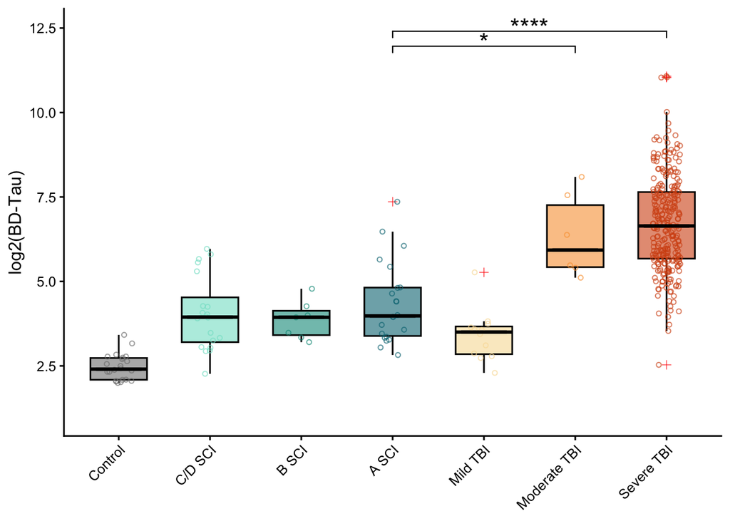

```r
p_serum_detail
```

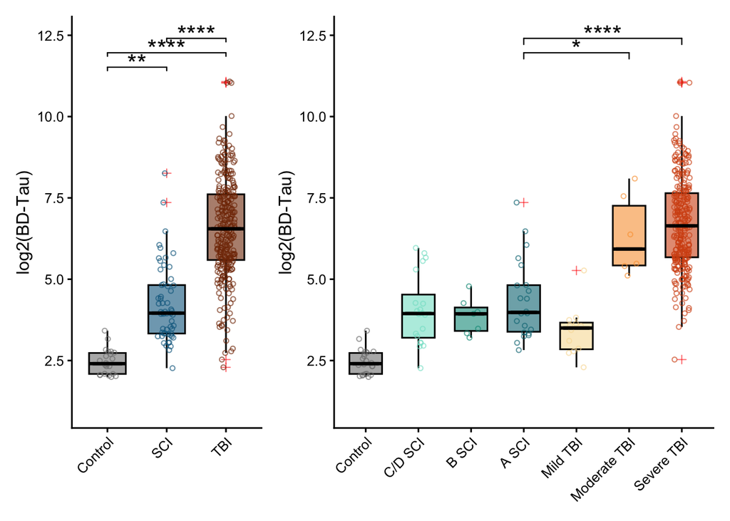

```r
library(patchwork)

# Combine plots with publication formatting
fig_combined <- p_serum + p_serum_detail +
  plot_layout(widths = c(1, 2)) +
  plot_annotation(
    # tag_levels = 'A',
    theme = theme(
      plot.tag = element_text(size = 14, face = "bold")
    )
  )

fig_combined
```

```r
# Spearman Correlation: Serum vs CSF BD-Tau

library(dplyr)
library(ggplot2)
library(ggpubr)
library(patchwork)
library(gt)
library(writexl)

# ============================================
# PREPARE MATCHED COHORT DATA
# ============================================

match_df <- match_baseline_cleaned %>%
  filter(!is.na(Cohort2),
         !is.na(mean_serum_BDTau),
         !is.na(mean_csf_BDTau)) %>%
  mutate(
    Cohort2 = factor(Cohort2, levels = c("SCI", "TBI")),
    Cohort3 = case_when(
      Cohort2 == "SCI" & !is.na(Subject.ID) & Subject.ID %in% asia_a_ids  ~ "A SCI",
      Cohort2 == "SCI" & !is.na(Subject.ID) & Subject.ID %in% asia_b_ids  ~ "B SCI",
      Cohort2 == "SCI" & !is.na(Subject.ID) & Subject.ID %in% asia_cd_ids ~ "C/D SCI",
      TRUE ~ as.character(Cohort)
    ),
    Cohort3 = factor(
      Cohort3,
      levels = c("C/D SCI", "B SCI", "A SCI", "Moderate TBI", "Severe TBI")
    )
  )

# ============================================
# SPEARMAN CORRELATION ANALYSIS
# ============================================

# Helper function to calculate Spearman CI using Fisher's Z transformation
spearman_ci <- function(x, y, conf.level = 0.95, digits = 2) {
  test_result <- cor.test(x, y, method = "spearman", exact = FALSE)
  rho <- as.numeric(test_result$estimate)
  n <- sum(complete.cases(x, y))

  # Fisher's Z transformation
  z <- 0.5 * log((1 + rho) / (1 - rho))
  se <- 1 / sqrt(n - 3)
  z_crit <- qnorm((1 + conf.level) / 2)

  # CI on Z scale
  z_lower <- z - z_crit * se
  z_upper <- z + z_crit * se

  # Transform back
  ci_lower <- (exp(2 * z_lower) - 1) / (exp(2 * z_lower) + 1)
  ci_upper <- (exp(2 * z_upper) - 1) / (exp(2 * z_upper) + 1)

  list(
    estimate = rho,
    conf.int = c(ci_lower, ci_upper),
    p.value = test_result$p.value,                         # numeric (for stats)
    p.value_sci = formatC(test_result$p.value,             # formatted (for reporting)
                          format = "e",
                          digits = digits),
    n = n
  )
}


# Overall correlation
cor_overall <- spearman_ci(match_df$mean_serum_BDTau,
                           match_df$mean_csf_BDTau)

# By cohort

cor_sci <- spearman_ci(
  match_df$mean_serum_BDTau[match_df$Cohort2 == "SCI"],
  match_df$mean_csf_BDTau[match_df$Cohort2 == "SCI"]
)

cor_tbi <- spearman_ci(
  match_df$mean_serum_BDTau[match_df$Cohort2 == "TBI"],
  match_df$mean_csf_BDTau[match_df$Cohort2 == "TBI"]
)

# Summary statistics by cohort

correlation_by_cohort <- match_df %>%
  group_by(Cohort2) %>%
  summarise(
    N = n(),
    Serum_Mean = mean(mean_serum_BDTau, na.rm = TRUE),
    Serum_SD = sd(mean_serum_BDTau, na.rm = TRUE),
    Serum_Median = median(mean_serum_BDTau, na.rm = TRUE),
    CSF_Mean = mean(mean_csf_BDTau, na.rm = TRUE),
    CSF_SD = sd(mean_csf_BDTau, na.rm = TRUE),
    CSF_Median = median(mean_csf_BDTau, na.rm = TRUE),
    .groups = "drop"
  )

print(correlation_by_cohort)
```

```
## # A tibble: 2 × 8
##   Cohort2     N Serum_Mean Serum_SD Serum_Median CSF_Mean CSF_SD CSF_Median
##   <fct>   <int>      <dbl>    <dbl>        <dbl>    <dbl>  <dbl>      <dbl>
## 1 SCI        30       25.4     30.5         15.1    1760.  2014.      1133.
## 2 TBI       228      180.     444.          81.8    6779.  9282.      3832.
```

```r
# Summary by subgroup
correlation_by_subgroup <- match_df %>%
  filter(!is.na(Cohort3)) %>%
  group_by(Cohort3) %>%
  summarise(
    N = n(),
    Serum_Mean = mean(mean_serum_BDTau, na.rm = TRUE),
    CSF_Mean = mean(mean_csf_BDTau, na.rm = TRUE),
    Spearman_rho = cor(mean_serum_BDTau, mean_csf_BDTau, method = "spearman"),
    .groups = "drop"
  )

print(correlation_by_subgroup)
```

```
## # A tibble: 5 × 5
##   Cohort3          N Serum_Mean CSF_Mean Spearman_rho
##   <fct>        <int>      <dbl>    <dbl>        <dbl>
## 1 C/D SCI          9       25.5     472.        0.217
## 2 B SCI            3       12.1    1251.        0.5
## 3 A SCI           16       28.5    2590.       -0.109
## 4 Moderate TBI     2       37.1     618.        1
## 5 Severe TBI     226      181.     6833.        0.188
```

```r
# ============================================
# PUBLICATION TABLE
# ============================================

# Create comprehensive correlation table
correlation_summary <- data.frame(
  Group = c("Overall", "SCI", "TBI"),
  N = c(cor_overall$n, cor_sci$n, cor_tbi$n),
  Spearman_rho = c(cor_overall$estimate, cor_sci$estimate, cor_tbi$estimate),
  CI_Lower = c(cor_overall$conf.int[1], cor_sci$conf.int[1], cor_tbi$conf.int[1]),
  CI_Upper = c(cor_overall$conf.int[2], cor_sci$conf.int[2], cor_tbi$conf.int[2]),
  P_value = c(cor_overall$p.value, cor_sci$p.value, cor_tbi$p.value)
)

# Format for publication
correlation_summary_formatted <- correlation_summary %>%
  mutate(
    `Spearman ρ (95% CI)` = sprintf("%.2f (%.2f-%.2f)",
                                    Spearman_rho, CI_Lower, CI_Upper),
    `P-value` = ifelse(P_value < 0.001, "<0.001",
                       sprintf("%.3f", P_value))
  ) %>%
  dplyr::select(Group, N, `Spearman ρ (95% CI)`, `P-value`)

print(correlation_summary_formatted)
```

```
##     Group   N Spearman ρ (95% CI) P-value
## 1 Overall 258    0.30 (0.19-0.41)  <0.001
## 2     SCI  30   0.12 (-0.25-0.46)   0.513
## 3     TBI 228    0.20 (0.07-0.32)   0.002
```

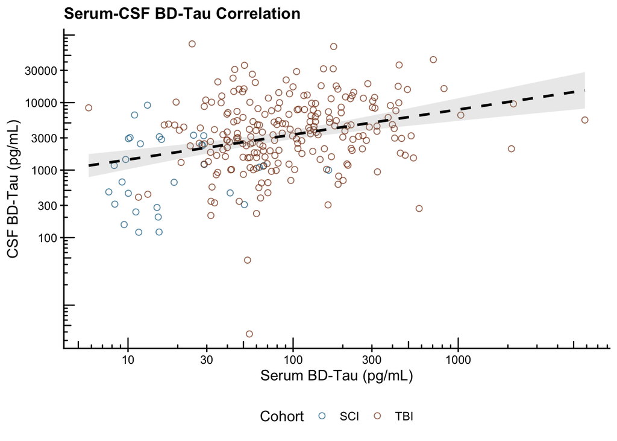

```r
# Create gt table
correlation_gt <- correlation_summary_formatted %>%
  gt() %>%
  tab_header(
    title = md("**Serum-CSF BD-Tau Correlation**"),
    subtitle = "Matched Cohort Analysis (Baseline)"
  ) %>%
  cols_label(
    Group = "Group",
    N = "N",
    `Spearman ρ (95% CI)` = "Spearman ρ (95% CI)",
    `P-value` = "P-value"
  ) %>%
  tab_style(
    style = cell_text(weight = "bold"),
    locations = cells_column_labels()
  ) %>%
  tab_options(
    table.font.size = 12,
    heading.title.font.size = 14
  ) %>%
  tab_footnote(
    footnote = "Spearman rank correlation on raw BD-Tau values (pg/mL)",
    locations = cells_column_labels(columns = `Spearman ρ (95% CI)`)
  )

# ============================================
# VISUALIZATION: SCATTER PLOT
# ============================================

# Define colors
cohort_colors <- c("SCI" = "#07668d", "TBI" = "#813405")

# Main scatter plot with log scales
p_correlation <- ggplot(match_df, aes(x = mean_serum_BDTau, y = mean_csf_BDTau)) +
  geom_point(aes(color = Cohort2), shape = 1, size = 2, alpha = 0.7) +
  geom_smooth(method = "lm", color = "black", linetype = "dashed",
              se = TRUE, alpha = 0.2, linewidth = 1) +
  scale_color_manual(values = cohort_colors) +
  scale_x_continuous(trans = "log10",
                     breaks = c(10, 30, 100, 300, 1000)) +
  scale_y_continuous(trans = "log10",
                     breaks = c(100, 300, 1000, 3000, 10000, 30000)) +
  annotation_logticks(sides = "bl") +
  labs(
    title = "Serum-CSF BD-Tau Correlation",
    x = "Serum BD-Tau (pg/mL)",
    y = "CSF BD-Tau (pg/mL)",
    color = "Cohort"
  ) +
  theme_classic(base_size = 12) +
  theme(
    legend.position = "bottom",
    #legend.background = element_rect(fill = "white", color = "black"),
    plot.title = element_text(face = "bold", size = 13),
    plot.subtitle = element_text(size = 10)
  )

print(p_correlation)
```

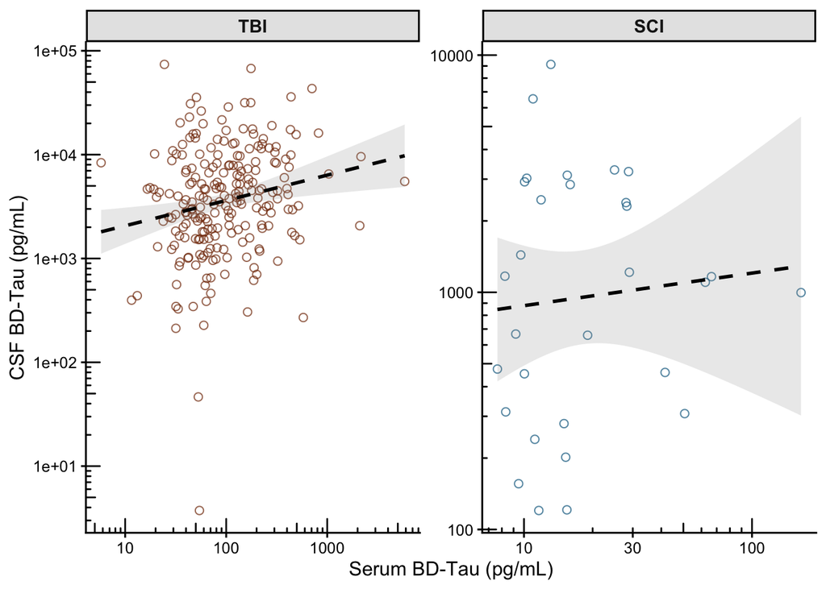

```r
# Faceted by cohort
p_by_cohort <- ggplot(match_df %>% mutate(Cohort2 = factor(Cohort2, levels = c("TBI","SCI"))), aes(x = mean_serum_BDTau, y = mean_csf_BDTau)) +
  geom_point(aes(color = Cohort2), shape = 1, size = 2, alpha = 0.7, show.legend = FALSE) +
  geom_smooth(method = "lm", color = "black", linetype = "dashed",
              se = TRUE, alpha = 0.2, linewidth = 1) +
  facet_wrap(~Cohort2, scales = "free") +
  scale_color_manual(values = cohort_colors) +
  scale_x_continuous(trans = "log10") +
  scale_y_continuous(trans = "log10") +
  annotation_logticks(sides = "bl") +
  labs(
    title = NULL,
    x = "Serum BD-Tau (pg/mL)",
    y = "CSF BD-Tau (pg/mL)"
  ) +
  theme_classic(base_size = 12) +
  theme(
    strip.background = element_rect(fill = "grey90"),
    strip.text = element_text(face = "bold", size = 11),
    plot.title = element_text(face = "bold")
  )

print(p_by_cohort)
```

```r
# ============================================
# Matched Serum/CSF Cohort Visualization
# ============================================

library(rstatix)
library(ggpubr)
library(ggplot2)
library(patchwork)
library(dplyr)

# Color palette
integrated_color_palette <- c(
  "Control" = "grey50",
  "A SCI" = "#007382",
  "B SCI" = "#019787",
  "C/D SCI" = "#82e1cd",
  "B-D SCI" = "#82e1cd",
  "Mild TBI" = "#f8dda4",
  "Moderate TBI" = "#f9a03f",
  "Severe TBI" = "#d45113"
)

cntr_tbi_color_palette <- c(
  "Control" = "grey50",
  "Moderate TBI" = "#f9a03f",
  "Severe TBI" = "#d45113"
  )

cntr_sci_color_palette <- c(
  "Control" = "grey50",
  "A SCI" = "#007382",
  "B SCI" = "#019787",
  "C/D SCI" = "#82e1cd"
  )

integrated_3color_palette <- c(
  "Control" = "grey50",
  "SCI" = "#07668d",
  "TBI" = "#813405"
)

match_df <- match_baseline_cleaned %>%
  filter(!is.na(Cohort2), !is.na(mean_serum_log2_BDTau)) %>%
  mutate(
    Cohort2 = factor(Cohort2, levels = names(integrated_3color_palette))) %>%
  mutate(
    Cohort3 = case_when(
      Cohort2 == "SCI" & !is.na(Subject.ID) & Subject.ID %in% asia_a_ids  ~ "A SCI",
      Cohort2 == "SCI" & !is.na(Subject.ID) & Subject.ID %in% asia_b_ids  ~ "B SCI",
      Cohort2 == "SCI" & !is.na(Subject.ID) & Subject.ID %in% asia_cd_ids ~ "C/D SCI",
      TRUE ~ as.character(Cohort)
    ),
    Cohort3 = factor(
      Cohort3,
      levels = c("Control", "C/D SCI", "B SCI", "A SCI", "Mild TBI", "Moderate TBI", "Severe TBI")
    ),
    Cohort4 = factor(case_when(
      Cohort3 %in% c("B SCI", "C/D SCI") ~ "B-D SCI",
      Cohort3 == "A SCI" ~ "A SCI",
      TRUE ~ Cohort3),
      levels = c("Control","B-D SCI","A SCI","Moderate TBI","Severe TBI"))
  )

csf_df <- csf_baseline_cleaned %>%
  filter(!is.na(Cohort2), !is.na(mean_csf_log2_BDTau)) %>%
  mutate(
    Cohort2 = factor(Cohort2, levels = names(integrated_3color_palette))) %>%
  mutate(
    Cohort3 = case_when(
      Cohort2 == "SCI" & !is.na(Subject.ID) & Subject.ID %in% asia_a_ids  ~ "A SCI",
      Cohort2 == "SCI" & !is.na(Subject.ID) & Subject.ID %in% asia_b_ids  ~ "B SCI",
      Cohort2 == "SCI" & !is.na(Subject.ID) & Subject.ID %in% asia_cd_ids ~ "C/D SCI",
      TRUE ~ as.character(Cohort)
    ),
    Cohort3 = factor(
      Cohort3,
      levels = c("Control", "C/D SCI", "B SCI", "A SCI", "Mild TBI", "Moderate TBI", "Severe TBI")
    ),
    Cohort4 = factor(case_when(
      Cohort3 %in% c("B SCI", "C/D SCI") ~ "B-D SCI",
      Cohort3 == "A SCI" ~ "A SCI",
      TRUE ~ Cohort3),
      levels = c("Control","B-D SCI","A SCI","Moderate TBI","Severe TBI"))
  )

# ============================================
# DATA PREPARATION
# ============================================

# Filter to only complete cases for 2-group analysis
match_df_2group <- match_df %>%
  filter(!is.na(Cohort2),
         !is.na(mean_serum_log2_BDTau),
         !is.na(mean_csf_log2_BDTau)) %>%
  mutate(Cohort2 = factor(Cohort2, levels = c("SCI", "TBI")))

# Check sample sizes
cat("Sample sizes for 2-group analysis:\n")
```

```
## Sample sizes for 2-group analysis:
```

```r
print(table(match_df_2group$Cohort2))
```

```
##
## SCI TBI
##  30 228
```

```r
cat("\n")
```

```r
fc_df <- match_df_2group %>%
  group_by(Cohort2) %>%
  summarise(
    serum_median = median(mean_serum_BDTau, na.rm = TRUE),
    csf_median   = median(mean_csf_BDTau,   na.rm = TRUE),
    .groups = "drop"
  ) %>%
  summarise(
    serum_FC = serum_median[Cohort2 == "TBI"] /
               serum_median[Cohort2 == "SCI"],
    csf_FC = csf_median[Cohort2 == "TBI"] /
               csf_median[Cohort2 == "SCI"],
    serum_log2FC = log2(serum_FC),
    csf_log2FC = log2(csf_FC)
  )

fc_df
```

```
## # A tibble: 1 × 4
##   serum_FC csf_FC serum_log2FC csf_log2FC
##      <dbl>  <dbl>        <dbl>      <dbl>
## 1     5.41   3.38         2.44       1.76
```

```r
# Filter for 5-group analysis
match_df_5group <- match_df %>%
  filter(!is.na(Cohort3),
         !is.na(mean_serum_log2_BDTau),
         !is.na(mean_csf_log2_BDTau)) %>%
  mutate(Cohort3 = factor(Cohort3,
                          levels = c("C/D SCI", "B SCI", "A SCI",
                                     "Moderate TBI", "Severe TBI")),
         Cohort4 = factor(Cohort4,
                          levels = c("B-D SCI","A SCI", "Moderate TBI", "Severe TBI")))

# Check sample sizes
cat("Sample sizes for 5-group analysis:\n")
```

```
## Sample sizes for 5-group analysis:
```

```r
print(table(match_df_5group$Cohort3))
```

```
##
##      C/D SCI        B SCI        A SCI Moderate TBI   Severe TBI
##            9            3           16            2          226
```

```r
cat("\n")
```

```r
# ============================================
# FIGURE 1: SERUM BD-TAU
# ============================================

# --------------------------------------------
# Panel A: Serum SCI vs TBI (2-group)
# --------------------------------------------

# Get summary by cohort
serum_match_summary_2group <- match_df_2group %>%
  group_by(Cohort2) %>%
  summarise(
    n = n(),
    mean_BDTau = mean(mean_serum_BDTau, na.rm = TRUE),
    sd_BDTau = sd(mean_serum_BDTau, na.rm = TRUE),
    median_BDTau = median(mean_serum_BDTau, na.rm = TRUE),
    p25_BDTau = quantile(mean_serum_BDTau, 0.25, na.rm = TRUE),
    p75_BDTau = quantile(mean_serum_BDTau, 0.75, na.rm = TRUE),
    min_BDTau = min(mean_serum_BDTau, na.rm = TRUE),
    max_BDTau = max(mean_serum_BDTau, na.rm = TRUE)
  )

# Statistical comparison - Mann-Whitney U test
wilcox_res_serum <- match_df_2group %>%
  wilcox_test(mean_serum_log2_BDTau ~ Cohort2, alternative = "two.sided") %>%
  add_significance("p")

W <- unname(wilcox_res_serum$statistic)
p <- wilcox_res_serum$p

W; p
```

```
## [1] 561
```

```
## [1] 1.01e-13
```

```r
y_max_serum_2g <- max(match_df_2group$mean_serum_log2_BDTau, na.rm = TRUE)

# Panel A: Serum SCI vs TBI
p_serum_2group <- ggplot(match_df_2group, aes(x = Cohort2, y = mean_serum_log2_BDTau,
                                              fill = Cohort2, color = Cohort2)) +
  geom_boxplot(width = 0.62, alpha = 0.6, outlier.shape = 3,
               outlier.color = "red", color = "black") +
  geom_jitter(width = 0.15, size = 1.2, shape = 1, alpha = 0.65, show.legend = FALSE) +
  stat_summary(fun = median, geom = "crossbar", width = 0.5, size = 0.45, color = "black") +
  scale_fill_manual(values = integrated_3color_palette, guide = "none") +
  scale_color_manual(values = integrated_3color_palette, guide = "none") +
  labs(x = NULL, y = "log2(BD-Tau)", title = NULL) +
  theme_classic(base_size = 12) +
  theme(
    axis.text.x = element_text(angle = 0, hjust = 0.5),
    plot.title = element_text(face = "bold", size = 13)
  ) +
  stat_compare_means(
    comparisons = list(c("SCI", "TBI")),
    method = "wilcox.test",
    label = "p.signif",
    tip.length = 0.02,
    bracket.size = 0.5,
    size = 6
  ) +
  annotate(
    "text",
    x = 1.5, y = y_max_serum_2g + 0.5,
    label = paste0("Mann-Whitney U p = ", signif(wilcox_res_serum$p, 3)),
    size = 3.6
  ) +
  ylim(1, 12.5)

# --------------------------------------------
# Panel B: Serum Subgroups (5-group)
# --------------------------------------------

# Get summary by subgroup
serum_match_summary_3group <- match_df %>%
  group_by(Cohort) %>%
  summarise(
    n = n(),
    mean_BDTau = mean(mean_serum_BDTau, na.rm = TRUE),
    sd_BDTau = sd(mean_serum_BDTau, na.rm = TRUE),
    median_BDTau = median(mean_serum_BDTau, na.rm = TRUE),
    p25_BDTau = quantile(mean_serum_BDTau, 0.25, na.rm = TRUE),
    p75_BDTau = quantile(mean_serum_BDTau, 0.75, na.rm = TRUE),
    min_BDTau = min(mean_serum_BDTau, na.rm = TRUE),
    max_BDTau = max(mean_serum_BDTau, na.rm = TRUE)
  )

# Statistical comparison
kw_res_serum_3g <- match_df %>%
  kruskal_test(mean_serum_log2_BDTau ~ Cohort)

dunn_res_serum_3g <- match_df %>%
  dunn_test(mean_serum_log2_BDTau ~ Cohort, p.adjust.method = "BH") %>%
  add_significance("p.adj") %>%
  arrange(group1, group2)

# Get summary by subgroup
serum_match_summary_5group <- match_df_5group %>%
  group_by(Cohort3) %>%
  summarise(
    n = n(),
    mean_BDTau = mean(mean_serum_BDTau, na.rm = TRUE),
    sd_BDTau = sd(mean_serum_BDTau, na.rm = TRUE),
    median_BDTau = median(mean_serum_BDTau, na.rm = TRUE),
    p25_BDTau = quantile(mean_serum_BDTau, 0.25, na.rm = TRUE),
    p75_BDTau = quantile(mean_serum_BDTau, 0.75, na.rm = TRUE),
    min_BDTau = min(mean_serum_BDTau, na.rm = TRUE),
    max_BDTau = max(mean_serum_BDTau, na.rm = TRUE)
  )

# Statistical comparison
kw_res_serum_5g <- match_df_5group %>%
  kruskal_test(mean_serum_log2_BDTau ~ Cohort3)

H <- unname(kw_res_serum_5g[["statistic"]])
df <- unname(kw_res_serum_5g[["df"]])
p <- unname(kw_res_serum_5g[["p"]])

H; df; p
```

```
## [1] 54.07192
```

```
## [1] 4
```

```
## [1] 5.08e-11
```

```r
dunn_res_serum_5g <- match_df_5group %>%
  dunn_test(mean_serum_log2_BDTau ~ Cohort3, p.adjust.method = "BH") %>%
  add_significance("p.adj") %>%
  arrange(group1, group2)

dunn_report <- dunn_res_serum_5g %>%
  dplyr::select(group1, group2, statistic, p, p.adj) %>%
  dplyr::mutate(
    z = statistic,
    p_raw = formatC(p, format = "e", digits = 2),
    p_bonf = formatC(p.adj, format = "e", digits = 2)
  ) %>%
  dplyr::select(group1, group2, z, p_raw, p_bonf)

dunn_report
```

```
## # A tibble: 10 × 5
##    group1       group2             z p_raw    p_bonf
##    <chr>        <chr>          <dbl> <chr>    <chr>
##  1 A SCI        Moderate TBI  0.384  7.01e-01 8.25e-01
##  2 A SCI        Severe TBI    5.49   4.03e-08 4.03e-07
##  3 B SCI        A SCI         0.494  6.21e-01 8.25e-01
##  4 B SCI        Moderate TBI  0.656  5.12e-01 8.25e-01
##  5 B SCI        Severe TBI    2.98   2.90e-03 9.65e-03
##  6 C/D SCI      A SCI        -0.0750 9.40e-01 9.40e-01
##  7 C/D SCI      B SCI        -0.513  6.08e-01 8.25e-01
##  8 C/D SCI      Moderate TBI  0.328  7.43e-01 8.25e-01
##  9 C/D SCI      Severe TBI    4.09   4.38e-05 2.19e-04
## 10 Moderate TBI Severe TBI    1.59   1.11e-01 2.77e-01
```

```r
y_max_serum_5g <- max(match_df_5group$mean_serum_log2_BDTau, na.rm = TRUE)
step_serum_5g  <- 0.04 * y_max_serum_5g
dunn_res_serum_5g <- dunn_res_serum_5g %>%
  mutate(y.position = y_max_serum_5g + row_number() * step_serum_5g)

# Panel B: Serum Subgroups
p_serum_5group <- ggplot(match_df_5group, aes(x = Cohort3, y = mean_serum_log2_BDTau,
                                              fill = Cohort3, color = Cohort3)) +
  geom_boxplot(width = 0.62, alpha = 0.6, outlier.shape = 3,
               outlier.color = "red", color = "black") +
  geom_jitter(width = 0.15, size = 1.2, shape = 1, alpha = 0.65, show.legend = FALSE) +
  stat_summary(fun = median, geom = "crossbar", width = 0.5, size = 0.45, color = "black") +
  scale_fill_manual(values = integrated_color_palette, guide = "none") +
  scale_color_manual(values = integrated_color_palette, guide = "none") +
  labs(x = NULL, y = "log2(BD-Tau)", title = NULL) +
  theme_classic(base_size = 12) +
  theme(
    axis.text.x = element_text(angle = 45, hjust = 1, vjust = 1),
    plot.title = element_text(face = "bold", size = 13)
  ) +
  ggpubr::stat_pvalue_manual(
    dunn_res_serum_5g,
    label = "p.adj.signif",
    xmin = "group1",
    xmax = "group2",
    y.position = "y.position",
    tip.length = 0.01,
    step.increase = 0.0,
    bracket.size = 0.4,
    size = 6,
    hide.ns = TRUE
  ) +
  annotate(
    "text",
    x = Inf, y = max(dunn_res_serum_5g$y.position, na.rm = TRUE) + 0.8 * step_serum_5g,
    label = paste0("Kruskal-Wallis p = ", signif(kw_res_serum_5g$p, 3)),
    hjust = 1, vjust = 0, size = 3.6
  ) +
  ylim(1, 12.5)

# Combine SERUM panels
fig_serum_matched <- p_serum_2group + p_serum_5group +
  plot_layout(widths = c(1, 2)) +
  plot_annotation(
    # tag_levels = 'A',
    # title = "Matched Cohort: Serum BD-Tau",
    theme = theme(
      plot.tag = element_text(size = 14, face = "bold"),
      plot.title = element_text(size = 15, face = "bold", hjust = 0.5)
    )
  )

# ============================================
# FIGURE 2: CSF BD-TAU
# ============================================

# --------------------------------------------
# Panel A: CSF SCI vs TBI (2-group)
# --------------------------------------------

# Get summary by cohort
csf_match_summary_2group <- match_df_2group %>%
  group_by(Cohort2) %>%
  summarise(
    n = n(),
    mean_BDTau = mean(mean_csf_BDTau, na.rm = TRUE),
    sd_BDTau = sd(mean_csf_BDTau, na.rm = TRUE),
    median_BDTau = median(mean_csf_BDTau, na.rm = TRUE),
    p25_BDTau = quantile(mean_csf_BDTau, 0.25, na.rm = TRUE),
    p75_BDTau = quantile(mean_csf_BDTau, 0.75, na.rm = TRUE),
    min_BDTau = min(mean_csf_BDTau, na.rm = TRUE),
    max_BDTau = max(mean_csf_BDTau, na.rm = TRUE)
  )

# Statistical comparison
wilcox_res_csf <- match_df_2group %>%
  wilcox_test(mean_csf_log2_BDTau ~ Cohort2, alternative = "two.sided") %>%
  add_significance("p")

W <- unname(wilcox_res_csf$statistic)
p <- wilcox_res_csf$p

W; p
```

```
## [1] 1454
```

```
## [1] 3.13e-07
```

```r
y_max_csf_2g <- max(match_df_2group$mean_csf_log2_BDTau, na.rm = TRUE)

# Panel A: CSF SCI vs TBI
p_csf_2group <- ggplot(match_df_2group, aes(x = Cohort2, y = mean_csf_log2_BDTau,
                                            fill = Cohort2, color = Cohort2)) +
  geom_boxplot(width = 0.62, alpha = 0.6, outlier.shape = 3,
               outlier.color = "red", color = "black") +
  geom_jitter(width = 0.15, size = 1.2, shape = 1, alpha = 0.65, show.legend = FALSE) +
  stat_summary(fun = median, geom = "crossbar", width = 0.5, size = 0.45, color = "black") +
  scale_fill_manual(values = integrated_3color_palette, guide = "none") +
  scale_color_manual(values = integrated_3color_palette, guide = "none") +
  labs(x = NULL, y = "log2(BD-Tau)", title = NULL) +
  theme_classic(base_size = 12) +
  theme(
    axis.text.x = element_text(angle = 0, hjust = 0.5),
    plot.title = element_text(face = "bold", size = 13)
  ) +
  stat_compare_means(
    comparisons = list(c("SCI", "TBI")),
    method = "wilcox.test",
    label = "p.signif",
    tip.length = 0.02,
    bracket.size = 0.5,
    size = 6
  ) +
  annotate(
    "text",
    x = 1.5, y = y_max_csf_2g + 0.5,
    label = paste0("Mann-Whitney U p = ", signif(wilcox_res_csf$p, 3)),
    size = 3.6
  ) +
  ylim(1, 12.5)

# --------------------------------------------
# Panel B: CSF Subgroups (5-group)
# --------------------------------------------

# Get summary by subgroup
csf_match_summary_5group <- match_df_5group %>%
  group_by(Cohort3) %>%
  summarise(
    n = n(),
    mean_BDTau = mean(mean_csf_BDTau, na.rm = TRUE),
    sd_BDTau = sd(mean_csf_BDTau, na.rm = TRUE),
    median_BDTau = median(mean_csf_BDTau, na.rm = TRUE),
    p25_BDTau = quantile(mean_csf_BDTau, 0.25, na.rm = TRUE),
    p75_BDTau = quantile(mean_csf_BDTau, 0.75, na.rm = TRUE),
    min_BDTau = min(mean_csf_BDTau, na.rm = TRUE),
    max_BDTau = max(mean_csf_BDTau, na.rm = TRUE)
  )

# Statistical comparison
kw_res_csf_4g <- match_df_5group %>%
  kruskal_test(mean_csf_log2_BDTau ~ Cohort4)

dunn_res_csf_4g <- match_df_5group %>%
  dunn_test(mean_csf_log2_BDTau ~ Cohort4, p.adjust.method = "BH") %>%
  add_significance("p.adj") %>%
  arrange(group1, group2)

kw_res_csf_5g <- match_df_5group %>%
  kruskal_test(mean_csf_log2_BDTau ~ Cohort3)

H <- unname(kw_res_csf_5g[["statistic"]])
df <- unname(kw_res_csf_5g[["df"]])
p <- unname(kw_res_csf_5g[["p"]])

H; df; p
```

```
## [1] 34.47405
```

```
## [1] 4
```

```
## [1] 5.96e-07
```

```r
dunn_res_csf_5g <- match_df_5group %>%
  dunn_test(mean_csf_log2_BDTau ~ Cohort3, p.adjust.method = "BH") %>%
  add_significance("p.adj") %>%
  arrange(group1, group2)

dunn_report <- dunn_res_csf_5g %>%
  dplyr::select(group1, group2, statistic, p, p.adj) %>%
  dplyr::mutate(
    z = statistic,
    p_raw = formatC(p, format = "e", digits = 2),
    p_bonf = formatC(p.adj, format = "e", digits = 2)
  ) %>%
  dplyr::select(group1, group2, z, p_raw, p_bonf)

dunn_report
```

```
## # A tibble: 10 × 5
##    group1       group2             z p_raw    p_bonf
##    <chr>        <chr>          <dbl> <chr>    <chr>
##  1 A SCI        Moderate TBI -1.15   2.48e-01 4.14e-01
##  2 A SCI        Severe TBI    2.53   1.15e-02 5.73e-02
##  3 B SCI        A SCI         0.840  4.01e-01 5.73e-01
##  4 B SCI        Moderate TBI -0.370  7.11e-01 7.91e-01
##  5 B SCI        Severe TBI    2.03   4.19e-02 8.37e-02
##  6 C/D SCI      A SCI         2.24   2.53e-02 8.08e-02
##  7 C/D SCI      B SCI         0.605  5.45e-01 6.81e-01
##  8 C/D SCI      Moderate TBI  0.0845 9.33e-01 9.33e-01
##  9 C/D SCI      Severe TBI    4.67   3.06e-06 3.06e-05
## 10 Moderate TBI Severe TBI    2.14   3.23e-02 8.08e-02
```

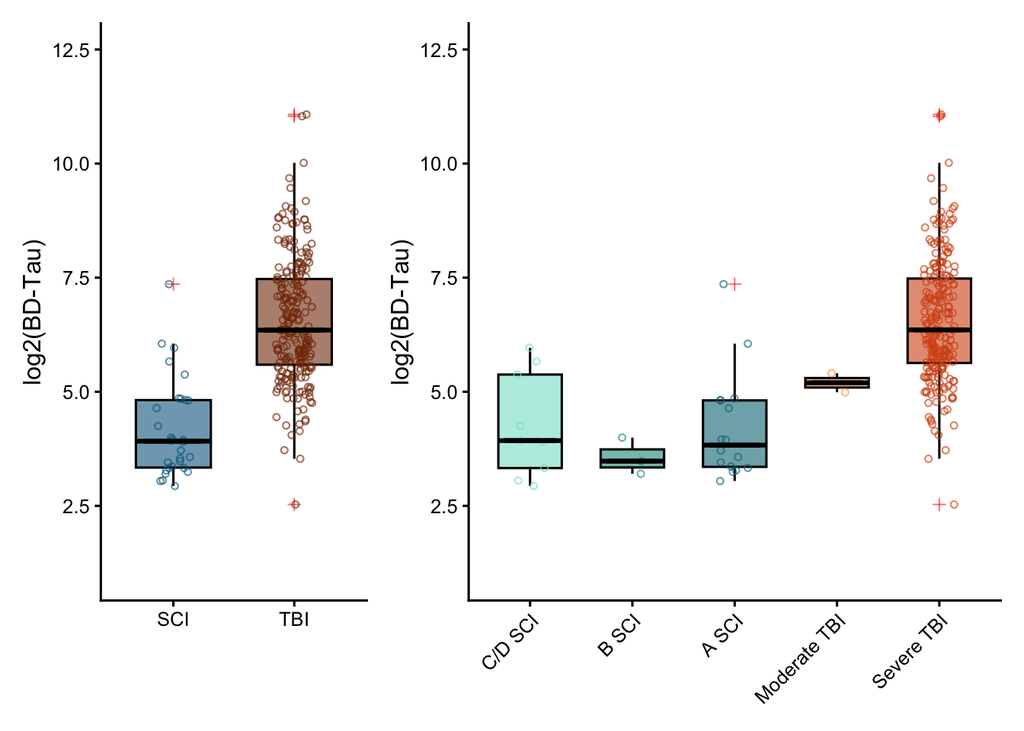

```r
y_max_csf_5g <- max(match_df_5group$mean_csf_log2_BDTau, na.rm = TRUE)
step_csf_5g  <- 0.04 * y_max_csf_5g
dunn_res_csf_5g <- dunn_res_csf_5g %>%
  mutate(y.position = y_max_csf_5g + row_number() * step_csf_5g)

# Panel B: CSF Subgroups
p_csf_5group <- ggplot(match_df_5group, aes(x = Cohort3, y = mean_csf_log2_BDTau,
                                            fill = Cohort3, color = Cohort3)) +
  geom_boxplot(width = 0.62, alpha = 0.6, outlier.shape = 3,
               outlier.color = "red", color = "black") +
  geom_jitter(width = 0.15, size = 1.2, shape = 1, alpha = 0.65, show.legend = FALSE) +
  stat_summary(fun = median, geom = "crossbar", width = 0.5, size = 0.45, color = "black") +
  scale_fill_manual(values = integrated_color_palette, guide = "none") +
  scale_color_manual(values = integrated_color_palette, guide = "none") +
  labs(x = NULL, y = "log2(BD-Tau)", title = NULL) +
  theme_classic(base_size = 12) +
  theme(
    axis.text.x = element_text(angle = 45, hjust = 1, vjust = 1),
    plot.title = element_text(face = "bold", size = 13)
  ) +
  ggpubr::stat_pvalue_manual(
    dunn_res_csf_5g,
    label = "p.adj.signif",
    xmin = "group1",
    xmax = "group2",
    y.position = "y.position",
    tip.length = 0.01,
    step.increase = 0.0,
    bracket.size = 0.4,
    size = 6,
    hide.ns = TRUE
  ) +
  annotate(
    "text",
    x = Inf, y = max(dunn_res_csf_5g$y.position, na.rm = TRUE) + 0.8 * step_csf_5g,
    label = paste0("Kruskal-Wallis p = ", signif(kw_res_csf_5g$p, 3)),
    hjust = 1, vjust = 0, size = 3.6
  ) +
  ylim(1, 12.5)

# Combine CSF panels
fig_csf_matched <- p_csf_2group + p_csf_5group +
  plot_layout(widths = c(1, 2)) +
  plot_annotation(
    # tag_levels = 'A',
    # title = "Matched Cohort: CSF BD-Tau",
    theme = theme(
      plot.tag = element_text(size = 14, face = "bold"),
      plot.title = element_text(size = 15, face = "bold", hjust = 0.5)
    )
  )

# ============================================
# DISPLAY FIGURES
# ============================================

print(fig_serum_matched)
```

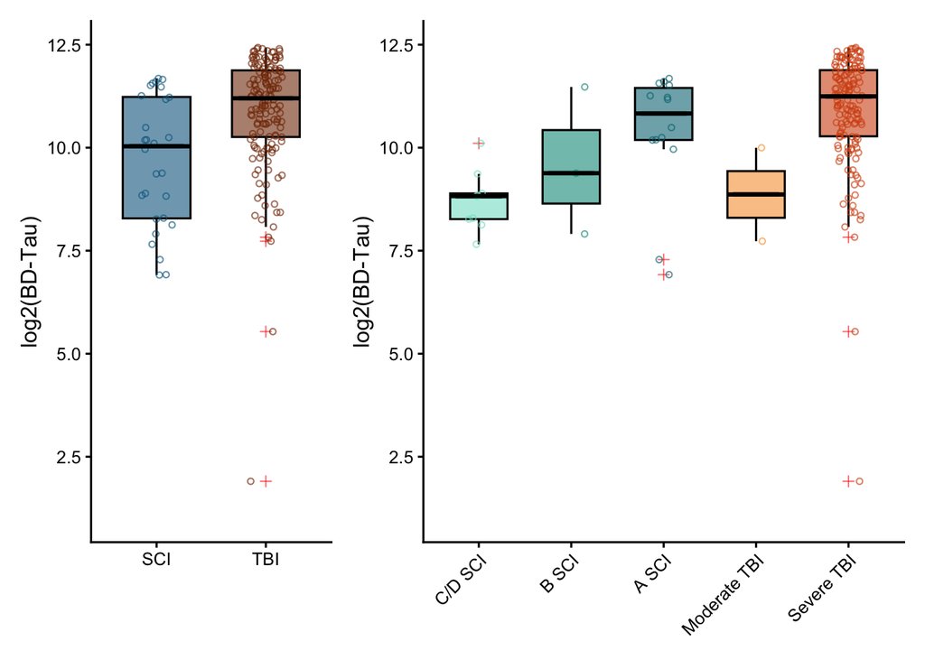

```r
print(fig_csf_matched)
```

```r
combined_fig <- p_serum_2group + p_serum_5group +
  p_csf_2group + p_csf_5group +
  plot_layout(widths = c(1, 2),
              heights = c(1, 1)) +
  plot_annotation(
    # tag_levels = 'A',
    title = NULL,
    theme = theme(
      plot.tag = element_text(size = 14, face = "bold"),
      plot.title = element_text(size = 15, face = "bold", hjust = 0.5)
    )
  )
```

```r
# ============================================
# ROC Analysis: Matched Cohort Only
# TBI vs SCI (Overall and Subgroups)
# INCLUDING MODERATE TBI
# Serum and CSF BD-Tau
# ============================================

library(pROC)
library(dplyr)
library(tidyr)
library(ggplot2)
library(gtsummary)
library(gt)
library(writexl)
library(patchwork)

# ============================================
# PREPARE DATA - MATCHED COHORT ONLY
# ============================================

# Filter to matched cohort with complete data
match_roc_data <- match_df %>%
  filter(!is.na(Cohort2),
         !is.na(Cohort3),
         !is.na(mean_serum_BDTau),
         !is.na(mean_csf_BDTau)) %>%
  mutate(
    Cohort2 = factor(Cohort2, levels = c("SCI", "TBI")),
    Cohort3 = factor(Cohort3,
                     levels = c("A SCI", "B SCI", "C/D SCI",
                                "Moderate TBI", "Severe TBI")),
    log2_serum_BDTau = log2(mean_serum_BDTau),
    z_log2_serum_BDTau = as.numeric(scale(log2_serum_BDTau)),
    log2_csf_BDTau = log2(mean_csf_BDTau),
    z_log2_csf_BDTau = as.numeric(scale(log2_csf_BDTau))
  )

# Check sample sizes
cat("\n=== MATCHED COHORT SAMPLE SIZES (INCLUDING MODERATE TBI) ===\n")
```

```
##
## === MATCHED COHORT SAMPLE SIZES (INCLUDING MODERATE TBI) ===
```

```r
cat("\n2-Group (Cohort2):\n")
```

```
##
## 2-Group (Cohort2):
```

```r
print(table(match_roc_data$Cohort2))
```

```
##
## SCI TBI
##  28 228
```

```r
cat("\n5-Group (Cohort3):\n")
```

```
##
## 5-Group (Cohort3):
```

```r
print(table(match_roc_data$Cohort3))
```

```
##
##        A SCI        B SCI      C/D SCI Moderate TBI   Severe TBI
##           16            3            9            2          226
```

```r
cat("\n")
```

```r
### Serum

# =============================================
# Adjusted Logistic ROC: BD-Tau ~ Age + Sex
# =============================================

# Helper to automate section creation

run_pairwise_roc_section <- function(data, cohort_var, pairs, section_label,
                                     n_folds = 5, n_boot = 1000, seed = 42) {
  set.seed(seed)

  purrr::map_dfr(pairs, function(pair) {
    df <- data %>%
      rename(cohort = {{cohort_var}}) %>%
      filter(cohort %in% pair) %>%
      mutate(
        outcome = as.numeric(cohort == pair[2]),
        Sex = factor(Sex, levels = c("Male", "Female"))
      ) %>%
      drop_na(z_log2_serum_BDTau, Age, Sex, outcome)

    if (length(unique(df$outcome)) < 2 || length(unique(df$Sex)) < 2) {
      return(tibble(
        Section = section_label,
        Comparison = paste(pair[2], "vs.", pair[1]),
        AUC = NA, CI_Lower = NA, CI_Upper = NA,
        N_Reference = sum(df$outcome == 0),
        N_Positive = sum(df$outcome == 1),
        Cutpoint = NA, NPV = NA, PPV = NA,
        Sensitivity = NA, Specificity = NA,
        Accuracy = NA,
        AUC_CV = NA, SD_CV = NA,
        AUC_Boot = NA, CI_Lower_Boot = NA, CI_Upper_Boot = NA
      ))
    }

    # Fit full model
    model <- glm(outcome ~ z_log2_serum_BDTau + Age + Sex, data = df, family = binomial())
    prob <- predict(model, type = "response")

    # Full ROC
    roc_obj <- pROC::roc(df$outcome, prob, levels = c(0, 1), direction = "<")
    ci_vals <- pROC::ci.auc(roc_obj)

    # Best cutpoint
    coords_best <- pROC::coords(roc_obj, "best", ret = "all", best.method = "youden")
    if (is.data.frame(coords_best) && nrow(coords_best) > 1) {
      coords_best <- coords_best[which.max(coords_best$sensitivity), ]
    }
    thr <- as.numeric(coords_best[["threshold"]])
    pred <- ifelse(prob >= thr, 1, 0)

    TP <- sum(pred == 1 & df$outcome == 1)
    TN <- sum(pred == 0 & df$outcome == 0)
    FP <- sum(pred == 1 & df$outcome == 0)
    FN <- sum(pred == 0 & df$outcome == 1)

    ## --------- Cross-validation ---------
    folds <- sample(rep(1:n_folds, length.out = nrow(df)))
    aucs_cv <- map_dbl(1:n_folds, function(i) {
      train <- df[folds != i, ]
      test <- df[folds == i, ]
      if (length(unique(train$outcome)) < 2 || length(unique(train$Sex)) < 2) return(NA)
      tryCatch({
        m_cv <- glm(outcome ~ z_log2_serum_BDTau + Age + Sex, data = train, family = binomial())
        prob_test <- predict(m_cv, newdata = test, type = "response")
        roc_cv <- pROC::roc(test$outcome, prob_test, levels = c(0, 1), direction = "<")
        as.numeric(pROC::auc(roc_cv))
      }, error = function(e) NA)
    })

    ## --------- Bootstrapping ---------
    aucs_boot <- map_dbl(1:n_boot, function(i) {
      boot_idx <- sample(seq_len(nrow(df)), replace = TRUE)
      df_boot <- df[boot_idx, ]
      if (length(unique(df_boot$outcome)) < 2 || length(unique(df_boot$Sex)) < 2) return(NA)
      tryCatch({
        m_boot <- glm(outcome ~ z_log2_serum_BDTau + Age + Sex, data = df_boot, family = binomial())
        prob_boot <- predict(m_boot, type = "response")
        roc_boot <- pROC::roc(df_boot$outcome, prob_boot, levels = c(0, 1), direction = "<")
        as.numeric(pROC::auc(roc_boot))
      }, error = function(e) NA)
    })

    tibble(
      Comparison = paste(pair[2], "vs.", pair[1]),

      AUC = as.numeric(roc_obj$auc),
      CI_Lower = ci_vals[1],
      CI_Upper = ci_vals[3],

      Sensitivity = coords_best[["sensitivity"]],
      Specificity = coords_best[["specificity"]],
      NPV = coords_best[["npv"]],
      PPV = coords_best[["ppv"]],
      Accuracy = (TP + TN) / (TP + TN + FP + FN),
      Cutpoint = thr,

      AUC_CV_Mean = mean(aucs_cv, na.rm = TRUE),
      AUC_CV_SD   = sd(aucs_cv, na.rm = TRUE),

      AUC_Boot_Mean  = mean(aucs_boot, na.rm = TRUE),
      AUC_Boot_SD    = sd(aucs_boot, na.rm = TRUE),
      AUC_Boot_Lower = quantile(aucs_boot, 0.025, na.rm = TRUE),
      AUC_Boot_Upper = quantile(aucs_boot, 0.975, na.rm = TRUE)
    )
  })
}

# Section 1: Control vs SCI vs TBI
section1_match_summary <- run_pairwise_roc_section(
  data = match_roc_data,
  cohort_var = Cohort2,
  pairs = list(c("SCI", "TBI")),
  section_label = "1. Primary 3-group"
)

# Section 2: Control vs SCI subgroups
# Section 3: Control vs TBI subgroups

# Section 4: SCI subgroup pairwise
section4_match_summary <- run_pairwise_roc_section(
  data = match_roc_data,
  cohort_var = Cohort3,
  pairs = list(c("B SCI", "A SCI"), c("C/D SCI", "A SCI"), c("C/D SCI", "B SCI")),
  section_label = "4. Pairwise SCI subgroups"
)

# Section 5: TBI subgroup pairwise
section5_match_summary <- run_pairwise_roc_section(
  data = match_roc_data,
  cohort_var = Cohort3,
  pairs = list(c("Moderate TBI", "Severe TBI")),
  section_label = "5. Pairwise TBI subgroups"
)

# Section 6: SCI vs TBI subgroups
section6_match_summary <- run_pairwise_roc_section(
  data = match_roc_data,
  cohort_var = Cohort,
  pairs = list(c("SCI", "Moderate TBI"), c("SCI", "Severe TBI")),
  section_label = "6. SCI vs. TBI subgroups"
)

# Combine all
all_roc_match_summary <- bind_rows(
  section1_match_summary,
  section4_match_summary,
  section5_match_summary,
  section6_match_summary
)

# Format for publication
all_roc_match_formatted <- all_roc_match_summary %>%
  mutate(
    AUC_CI = sprintf("%.3f (%.3f-%.3f)", AUC, CI_Lower, CI_Upper),
    Cutpoint = sprintf("%.2f", Cutpoint),
    Sensitivity = sprintf("%.3f", Sensitivity),
    Specificity = sprintf("%.3f", Specificity)
  ) %>%
  dplyr::select(Comparison, AUC, CI_Lower, CI_Upper, Sensitivity, Specificity,
                NPV, PPV, Accuracy, Cutpoint,
                AUC_CV_Mean, AUC_CV_SD, AUC_Boot_Mean, AUC_Boot_SD, AUC_Boot_Lower, AUC_Boot_Upper)

# =============================================
# Adjusted Logistic ROC: BD-Tau ~ Age + Sex
# =============================================

# Helper to automate section creation

run_pairwise_roc_section <- function(data, cohort_var, pairs, section_label,
                                     n_folds = 5, n_boot = 1000, seed = 42) {
  set.seed(seed)
```

```r
  purrr::map_dfr(pairs, function(pair) {
    df <- data %>%
      rename(cohort = {{cohort_var}}) %>%
      filter(cohort %in% pair) %>%
      mutate(
        outcome = as.numeric(cohort == pair[2]),
        Sex = factor(Sex, levels = c("Male", "Female"))
      ) %>%
      drop_na(z_log2_csf_BDTau, Age, Sex, outcome)

    if (length(unique(df$outcome)) < 2 || length(unique(df$Sex)) < 2) {
      return(tibble(
        Section = section_label,
        Comparison = paste(pair[2], "vs.", pair[1]),
        AUC = NA, CI_Lower = NA, CI_Upper = NA,
        N_Reference = sum(df$outcome == 0),
        N_Positive = sum(df$outcome == 1),
        Cutpoint = NA, NPV = NA, PPV = NA,
        Sensitivity = NA, Specificity = NA,
        Accuracy = NA,
        AUC_CV = NA, SD_CV = NA,
        AUC_Boot = NA, CI_Lower_Boot = NA, CI_Upper_Boot = NA
      ))
    }

    # Fit full model
    model <- glm(outcome ~ z_log2_csf_BDTau + Age + Sex, data = df, family = binomial())
    prob <- predict(model, type = "response")

    # Full ROC
    roc_obj <- pROC::roc(df$outcome, prob, levels = c(0, 1), direction = "<")
    ci_vals <- pROC::ci.auc(roc_obj)

    # Best cutpoint
    coords_best <- pROC::coords(roc_obj, "best", ret = "all", best.method = "youden")
    if (is.data.frame(coords_best) && nrow(coords_best) > 1) {
      coords_best <- coords_best[which.max(coords_best$sensitivity), ]
    }
    thr <- as.numeric(coords_best[["threshold"]])
    pred <- ifelse(prob >= thr, 1, 0)

    TP <- sum(pred == 1 & df$outcome == 1)
    TN <- sum(pred == 0 & df$outcome == 0)
    FP <- sum(pred == 1 & df$outcome == 0)
    FN <- sum(pred == 0 & df$outcome == 1)

    ## --------- Cross-validation ---------
    folds <- sample(rep(1:n_folds, length.out = nrow(df)))
    aucs_cv <- map_dbl(1:n_folds, function(i) {
      train <- df[folds != i, ]
      test <- df[folds == i, ]
      if (length(unique(train$outcome)) < 2 || length(unique(train$Sex)) < 2) return(NA)
      tryCatch({
        m_cv <- glm(outcome ~ z_log2_csf_BDTau + Age + Sex, data = train, family = binomial())
        prob_test <- predict(m_cv, newdata = test, type = "response")
        roc_cv <- pROC::roc(test$outcome, prob_test, levels = c(0, 1), direction = "<")
        as.numeric(pROC::auc(roc_cv))
      }, error = function(e) NA)
    })

    ## --------- Bootstrapping ---------
    aucs_boot <- map_dbl(1:n_boot, function(i) {
      boot_idx <- sample(seq_len(nrow(df)), replace = TRUE)
      df_boot <- df[boot_idx, ]
      if (length(unique(df_boot$outcome)) < 2 || length(unique(df_boot$Sex)) < 2) return(NA)
      tryCatch({
        m_boot <- glm(outcome ~ z_log2_csf_BDTau + Age + Sex, data = df_boot, family = binomial())
        prob_boot <- predict(m_boot, type = "response")
        roc_boot <- pROC::roc(df_boot$outcome, prob_boot, levels = c(0, 1), direction = "<")
        as.numeric(pROC::auc(roc_boot))
      }, error = function(e) NA)
    })

    tibble(
      Comparison = paste(pair[2], "vs.", pair[1]),

      AUC = as.numeric(roc_obj$auc),
      CI_Lower = ci_vals[1],
      CI_Upper = ci_vals[3],

      Sensitivity = coords_best[["sensitivity"]],
      Specificity = coords_best[["specificity"]],
      NPV = coords_best[["npv"]],
      PPV = coords_best[["ppv"]],
      Accuracy = (TP + TN) / (TP + TN + FP + FN),
      Cutpoint = thr,

      AUC_CV_Mean = mean(aucs_cv, na.rm = TRUE),
      AUC_CV_SD   = sd(aucs_cv, na.rm = TRUE),

      AUC_Boot_Mean  = mean(aucs_boot, na.rm = TRUE),
      AUC_Boot_SD    = sd(aucs_boot, na.rm = TRUE),
      AUC_Boot_Lower = quantile(aucs_boot, 0.025, na.rm = TRUE),
      AUC_Boot_Upper = quantile(aucs_boot, 0.975, na.rm = TRUE)
    )
  })
}

# Section 1: Control vs SCI vs TBI
section1_csf_match_summary<- run_pairwise_roc_section(
  data = match_roc_data,
  cohort_var = Cohort2,
  pairs = list(c("SCI", "TBI")),
  section_label = "1. Primary 3-group"
)

# Section 2: Control vs SCI subgroups
# Section 3: Control vs TBI subgroups

# Section 4: SCI subgroup pairwise
section4_csf_match_summary<- run_pairwise_roc_section(
  data = match_roc_data,
  cohort_var = Cohort3,
  pairs = list(c("B SCI", "A SCI"), c("C/D SCI", "A SCI"), c("C/D SCI", "B SCI")),
  section_label = "4. Pairwise SCI subgroups"
)

# Section 5: TBI subgroup pairwise
section5_csf_match_summary<- run_pairwise_roc_section(
  data = match_roc_data,
  cohort_var = Cohort3,
  pairs = list(c("Moderate TBI", "Severe TBI")),
  section_label = "5. Pairwise TBI subgroups"
)

# Section 6: SCI vs TBI subgroups
section6_csf_match_summary<- run_pairwise_roc_section(
  data = match_roc_data,
  cohort_var = Cohort,
  pairs = list(c("SCI", "Moderate TBI"), c("SCI", "Severe TBI")),
  section_label = "6. SCI vs. TBI subgroups"
)

# Combine all
all_roc_csf_match_summary<- bind_rows(
  section1_csf_match_summary,
  section4_csf_match_summary,
  section5_csf_match_summary,
  section6_csf_match_summary
)

# Format for publication
all_roc_csf_match_formatted <- all_roc_csf_match_summary%>%
  mutate(
    AUC_CI = sprintf("%.3f (%.3f-%.3f)", AUC, CI_Lower, CI_Upper),
    Cutpoint = sprintf("%.2f", Cutpoint),
    Sensitivity = sprintf("%.3f", Sensitivity),
    Specificity = sprintf("%.3f", Specificity)
  ) %>%
  dplyr::select(Comparison, AUC, CI_Lower, CI_Upper, Sensitivity, Specificity,
                NPV, PPV, Accuracy, Cutpoint,
                AUC_CV_Mean, AUC_CV_SD, AUC_Boot_Mean, AUC_Boot_SD, AUC_Boot_Lower, AUC_Boot_Upper)

matched_summary <- rbind(all_roc_match_summary %>% mutate(Platform = "Serum"),
                         all_roc_csf_match_summary %>% mutate(Platform = "CSF")) %>%
  filter(Comparison %in% c("TBI vs. SCI", "Severe TBI vs. SCI",
                           "A SCI vs. B SCI", "A SCI vs. C/D SCI", "B SCI vs. C/D SCI"))

forest_data <- matched_summary %>%
  mutate(
    Comparison = factor(Comparison, levels = c(
      "TBI vs. SCI","Severe TBI vs. SCI",
      "A SCI vs. B SCI", "A SCI vs. C/D SCI",
      "B SCI vs. C/D SCI"
    )),
    Group = paste0(Platform, " ", Comparison)
  )
```

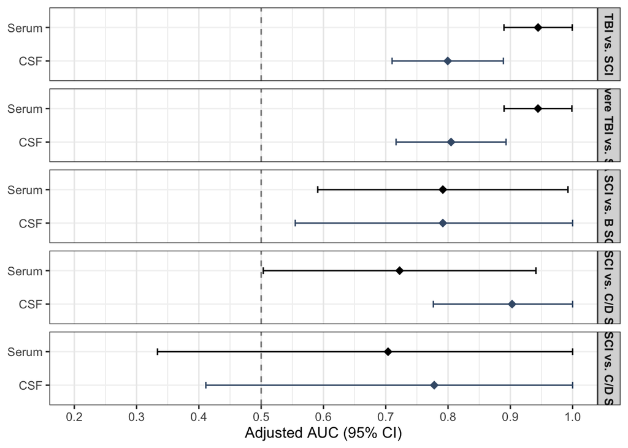

```r
group_cols <- c(
  "Serum" = "black",
  "CSF" = "#415a77"
)

# Plot
p_adj_forest <- ggplot(forest_data, aes(x = AUC, y = Platform)) +
  geom_vline(xintercept = 0.5, linetype = "dashed", color = "gray50") +
  geom_errorbarh(aes(xmin = CI_Lower, xmax = CI_Upper, color = Platform), height = 0.2) +
  geom_point(aes(color = Platform), size = 3, shape = 18) +
  scale_x_continuous(limits = c(0.2, 1), breaks = seq(0.2, 1.0, 0.1)) +
  facet_grid(Comparison ~ ., scales = "free_y", space = "free_y") +
  scale_color_manual(values = group_cols) +
  labs(x = "Adjusted AUC (95% CI)", y = NULL) +
  theme_bw(base_size = 12) +
  theme(
    legend.position = "none",
    strip.text = element_text(face = "bold"),
    panel.grid.major.y = element_line(color = "grey95")
  )

# Print
print(p_adj_forest)
```

```r
# Save
pdf("~/Desktop/Projects/manuscript writing/TBI BD-tau/figure/Extended Data Figure 1.pdf",
    height = 11.69/3, width = 8.27*0.8)
print(p_adj_forest)
dev.off()
```

```r
# =============================================
# DeLong: Serum vs. CSF within each comparison
# (paired, because both fluids are measured on
#  the same matched subjects)
# Compares the adjusted models BD-Tau + Age + Sex
# =============================================

serum_vs_csf_delong <- function(data, cohort_var, pair) {
  df <- data %>%
    rename(cohort = !!rlang::sym(cohort_var)) %>%
    filter(cohort %in% pair) %>%
    mutate(
      outcome = as.numeric(cohort == pair[2]),
      Sex     = factor(Sex, levels = c("Male", "Female"))
    ) %>%
    # drop on BOTH biomarkers so the two ROCs are on identical cases (required for paired DeLong)
    drop_na(z_log2_serum_BDTau, z_log2_csf_BDTau, Age, Sex, outcome)

  if (length(unique(df$outcome)) < 2 || length(unique(df$Sex)) < 2 || nrow(df) < 5) {
    return(tibble(
      Comparison = paste(pair[2], "vs.", pair[1]),
      N = nrow(df), AUC_Serum = NA_real_, AUC_CSF = NA_real_,
      DeLong_Z = NA_real_, DeLong_P = NA_real_
    ))
  }

  m_serum <- glm(outcome ~ z_log2_serum_BDTau + Age + Sex, data = df, family = binomial())
  m_csf   <- glm(outcome ~ z_log2_csf_BDTau   + Age + Sex, data = df, family = binomial())

  roc_serum <- pROC::roc(df$outcome, predict(m_serum, type = "response"),
                         levels = c(0, 1), direction = "<")
  roc_csf   <- pROC::roc(df$outcome, predict(m_csf,   type = "response"),
                         levels = c(0, 1), direction = "<")

  test <- pROC::roc.test(roc_serum, roc_csf, method = "delong", paired = TRUE)

  tibble(
    Comparison = paste(pair[2], "vs.", pair[1]),
    N          = nrow(df),
    AUC_Serum  = as.numeric(roc_serum$auc),
    AUC_CSF    = as.numeric(roc_csf$auc),
    DeLong_Z   = unname(test$statistic),
    DeLong_P   = test$p.value
  )
}

# Mirror the exact pairs/cohort vars used in the sections so labels match the forest plot
delong_specs <- list(
  list(cohort_var = "Cohort2", pair = c("SCI", "TBI")),          # -> "TBI vs. SCI"
  list(cohort_var = "Cohort",  pair = c("SCI", "Severe TBI")),   # -> "Severe TBI vs. SCI"
  list(cohort_var = "Cohort3", pair = c("B SCI",   "A SCI")),    # -> "A SCI vs. B SCI"
  list(cohort_var = "Cohort3", pair = c("C/D SCI", "A SCI")),    # -> "A SCI vs. C/D SCI"
  list(cohort_var = "Cohort3", pair = c("C/D SCI", "B SCI"))     # -> "B SCI vs. C/D SCI"
)

serum_vs_csf_delong_results <- purrr::map_dfr(
  delong_specs,
  ~ serum_vs_csf_delong(match_roc_data, .x$cohort_var, .x$pair)
) %>%
  mutate(
    P_adj = p.adjust(DeLong_P, method = "BH"),   # optional: drop if you don't want multiplicity adjustment
    P_label = ifelse(DeLong_P < 0.001, "<0.001", sprintf("%.3f", DeLong_P)),
    delta_AUC = AUC_Serum - AUC_CSF
  )

print(serum_vs_csf_delong_results)
```

```
## # A tibble: 5 × 9
##   Comparison      N AUC_Serum AUC_CSF DeLong_Z DeLong_P  P_adj P_label delta_AUC
##   <chr>       <int>     <dbl>   <dbl>    <dbl>    <dbl>  <dbl> <chr>       <dbl>
## 1 TBI vs. SCI   256     0.945   0.799    2.76   0.00575 0.0197 0.006      0.145
## 2 Severe TBI…   254     0.944   0.805    2.66   0.00788 0.0197 0.008      0.140
## 3 A SCI vs. …    19     0.792   0.792    0      1       1      1.000      0
## 4 A SCI vs. …    25     0.722   0.903   -1.59   0.113   0.188  0.113     -0.181
## 5 B SCI vs. …    12     0.704   0.778   -0.431  0.666   0.833  0.666     -0.0741
```

```r
# ----- load dataset -----

# load commercial bd-tau (TBI/SCI cohort)

commercial_bdtau <- bind_rows(
  tbi_serum_demo %>% dplyr::select(Subject.ID, Subject.Visit, Cohort, Age, Sex, serum_BDTau, serum_Raw_Day_Value),
  sci_serum_demo %>% dplyr::select(Subject.ID, Subject.Visit, Cohort, Age, Sex, serum_BDTau, serum_Raw_Day_Value),
  cntr_cleaned %>% dplyr::select(Subject.ID, Subject.Visit, Cohort, Age, Sex, serum_BDTau, serum_Raw_Day_Value)) %>%
  mutate(Subject.Visit = ifelse(suppressWarnings(!is.na(as.numeric(Subject.Visit))),
                                sprintf("%.2f", as.numeric(Subject.Visit)),
                                Subject.Visit %>%
                                  # Case 1: SP-01-####-C-XX → SP-01-####.C
                                  str_replace("^((?:SP-\\d+-\\d+))-(\\w)-.*$", "\\1.\\2") %>%
                                  # Case 2: ST-####-+CODE-XX → ST-####.CODE
                                  str_replace("^([A-Z]+-\\d+)-\\+([A-Z0-9]+)-.*$", "\\1.\\2") %>%
                                  # Case 3: ST-####-CODE-XX → ST-####.CODE  (SCS, etc.)
                                  str_replace("^([A-Z]+-\\d+)-([A-Z0-9]{2,})-.*$", "\\1.\\2") %>%
                                  # Case 4: ST-####-C-XX → ST-####.C
                                  str_replace("^([A-Z]+-\\d+)-([A-Z])-.*$","\\1.\\2")
                                 )
    ) %>%
  filter(!is.na(serum_BDTau)) %>%
  group_by(Subject.ID, Subject.Visit) %>%
  arrange(desc(!is.na(serum_Raw_Day_Value)), .by_group = TRUE) %>%
  slice(1) %>%
  ungroup() %>%
  distinct()

sapply(commercial_bdtau, function(x) sum(is.na(x)))
```

```
##          Subject.ID       Subject.Visit              Cohort                 Age
##                   0                   0                   0                   0
##                 Sex         serum_BDTau serum_Raw_Day_Value
##                   0                   0                 102
```

```r
# load N4PD bd-tau

setwd("~/Desktop/Projects/2025_05_19_TBI_SCI_BDTau/Raw_Data/N4PD")

n4pd_vars <- c("BD-tau_N4PD","GFAP_N4PD","NfL_N4PD","UCH-L1_N4PD")
bmkrs <- c("BD-tau (pg/ml)", n4pd_vars)

sTBI_N4PD <- read_excel("TBI SCI_N4PD_Results_11212025.xlsx", sheet = 1) %>%
  mutate(Cohort = "Severe TBI",
         `Subject ID` = as.character(`Subject ID`),
         `Specimen ID` = as.character(`Specimen ID`),
         `Time From Injury` = as.numeric(`Time From Injury`)) %>%
  mutate(across(n4pd_vars, ~suppressWarnings(as.numeric(as.character(.))))) %>%
  dplyr::select(`Subject ID`, `Specimen ID`,
                `Time From Injury`, bmkrs, Cohort)

SCI_N4PD <- read_excel("TBI SCI_N4PD_Results_11212025.xlsx", sheet = 2) %>%
  mutate(Cohort = "SCI",
         `Time From Injury` = as.numeric(`Time From Injury`)) %>%
  mutate(across(n4pd_vars, ~suppressWarnings(as.numeric(as.character(.))))) %>%
  rename(`Subject ID` = `Participant ID`) %>%
  dplyr::select(`Subject ID`, `Specimen ID`,
                `Time From Injury`, bmkrs, Cohort)

mTBI_N4PD <- read_excel("TBI SCI_N4PD_Results_11212025.xlsx", sheet = 3) %>%
  mutate(Cohort = case_when(Group == "Controls" ~ "Control",
                            Group == "Mild" ~ "Mild TBI",
                            Group == "Severe" ~ "Severe TBI",
                            TRUE ~ NA_character_),
         `Specimen ID` = `Current Label`,
         `Time From Injury` = NA_real_,
         `BD-tau (pg/ml)` = `BD-tau_June2025`) %>%
  mutate(across(n4pd_vars, ~suppressWarnings(as.numeric(as.character(.))))) %>%
  dplyr::select(`Subject ID`, `Specimen ID`,
                `Time From Injury`, bmkrs, Cohort)

n4pd_bdtau <- bind_rows(
  sTBI_N4PD, SCI_N4PD, mTBI_N4PD) %>%
  # drop_na(all_of(bmkrs)) %>%
  mutate(Days_From_Injury = case_when(!is.na(`Time From Injury`) ~ `Time From Injury`/24,
                                      Cohort == 0 ~ 0,
                                      grepl("-A-", `Specimen ID`) ~ 0,
                                      grepl("-D-", `Specimen ID`) ~ 14,
                                      grepl(".B.", `Specimen ID`) ~ 90,
                                      grepl(".C.", `Specimen ID`) ~ 180),
        Subject.Visit = ifelse(suppressWarnings(!is.na(as.numeric(`Specimen ID`))),
                                sprintf("%.2f", as.numeric(`Specimen ID`)),
                                `Specimen ID` %>%
                                  # Case 1: SP-01-####-C-XX → SP-01-####.C
                                  str_replace("^((?:SP-\\d+-\\d+))-(\\w)-.*$", "\\1.\\2") %>%
                                  # Case 2: ST-####-+CODE-XX → ST-####.CODE
                                  str_replace("^([A-Z]+-\\d+)-\\+([A-Z0-9]+)-.*$", "\\1.\\2") %>%
                                  # Case 3: ST-####-CODE-XX → ST-####.CODE  (SCS, etc.)
                                  str_replace("^([A-Z]+-\\d+)-([A-Z0-9]{2,})-.*$", "\\1.\\2") %>%
                                  # Case 4: ST-####-C-XX → ST-####.C
                                  str_replace("^([A-Z]+-\\d+)-([A-Z])-.*$","\\1.\\2")
                                 ),
         Subject.ID = case_when(
           # SP-01-1004-A-10S -> SP-1004
           str_detect(`Specimen ID`, "^SP-01-") ~
             str_replace(`Specimen ID`, "^SP-01-(\\d+).*", "SP-\\1"),

           # CTE-027-07S -> CTE-027
           str_detect(`Specimen ID`, "^CTE-") ~
             str_replace(`Specimen ID`, "^(CTE-\\d+).*", "\\1"),

           # MCS-1021-A-07S -> MCS-1021
           str_detect(`Specimen ID`, "^MCS-") ~
             str_replace(`Specimen ID`, "^(MCS-\\d+).*", "\\1"),

           # ST-1001-+36-09S -> ST-1001
           str_detect(`Specimen ID`, "^ST-") ~
           str_replace(`Specimen ID`, "^(ST-\\d+).*", "\\1"),

           TRUE ~ str_remove(`Specimen ID`, "\\..*$"))
    ) %>%
  rename(n4pd_BDtau_conc = `BD-tau_N4PD`) %>%
  dplyr::select(Subject.ID, Subject.Visit, `BD-tau (pg/ml)`, n4pd_BDtau_conc,
                GFAP_N4PD, NfL_N4PD, `UCH-L1_N4PD`)

sapply(n4pd_bdtau, function(x) sum(is.na(x)))
```

```
##      Subject.ID   Subject.Visit  BD-tau (pg/ml) n4pd_BDtau_conc       GFAP_N4PD
##               0               0             214             239             239
##        NfL_N4PD     UCH-L1_N4PD
##             239             269
```

```r
# ----- merge together -----

bdtau_conc <- commercial_bdtau %>%
  filter(!is.na(serum_BDTau)) %>%
  dplyr::select(Subject.ID, Subject.Visit, Cohort, Sex, Age, serum_BDTau) %>%
  inner_join(n4pd_bdtau, by = c("Subject.ID", "Subject.Visit")) %>%
  distinct()

sapply(bdtau_conc, function(x) sum(is.na(x)))
```

```
##      Subject.ID   Subject.Visit          Cohort             Sex             Age
##               0               0               0               0               0
##     serum_BDTau  BD-tau (pg/ml) n4pd_BDtau_conc       GFAP_N4PD        NfL_N4PD
##               0             185             224             224             224
##     UCH-L1_N4PD
##             254
```

```r
# clean up demographics

bdtau_demo <- bdtau_conc %>%
  group_by(Subject.ID) %>%
  summarise(
    Cohort = first(na.omit(Cohort)),
    Age = first(na.omit(Age)),
    Sex = first(na.omit(Sex)),
    .groups = "drop"
  ) %>% distinct() %>%
  filter(!is.na(Sex))

bdtau <- bdtau_conc %>%
  dplyr::select(-Cohort, -Age, -Sex) %>%
  left_join(bdtau_demo, by = "Subject.ID") %>%
  filter(!is.na(Sex)) %>%
  mutate(
    commercial_BDtau_conc = serum_BDTau,
    n4pd_BDtau_conc = n4pd_BDtau_conc
  ) %>%
  # filter(commercial_BDtau_flag != "inconsistency" | is.na(commercial_BDtau_flag)) %>%
  dplyr::select(Subject.ID, Subject.Visit, Cohort, Sex, Age,
                commercial_BDtau_conc, n4pd_BDtau_conc, GFAP_N4PD, NfL_N4PD, `UCH-L1_N4PD`) %>%
  mutate(
    across(where(is.character), ~ stringr::str_squish(.x)),
    across(where(is.numeric),  ~ round(.x, 6))
  ) %>%
  distinct()

dup_ids <- bdtau$Subject.Visit[duplicated(bdtau$Subject.Visit)]

bdtau_clean <- bdtau %>%
  # remove subjects have conflict values
  filter(!(Subject.Visit %in% dup_ids)) %>%
  filter(!is.na(n4pd_BDtau_conc) & !is.na(`UCH-L1_N4PD`))

sapply(bdtau_clean, function(x) sum(is.na(x)))
```

```
##            Subject.ID         Subject.Visit                Cohort
##                     0                     0                     0
##                   Sex                   Age commercial_BDtau_conc
##                     0                     0                     0
##       n4pd_BDtau_conc             GFAP_N4PD              NfL_N4PD
##                     0                     0                     0
##           UCH-L1_N4PD
##                     0
```

```r
# count number of visits

n_visits <- bdtau_clean %>%
  group_by(Subject.ID) %>%
  summarise(
    n_visits = n_distinct(Subject.Visit),
    .groups = "drop"
  )

bdtau_conc_baseline <- bdtau_clean %>%
  filter(
    # !is.na(inhouse_BDtau_conc),
    !is.na(commercial_BDtau_conc),
    # !is.na(n4pd_BDtau_conc)
    !is.na(n4pd_BDtau_conc)
  ) %>%
  group_by(Subject.ID) %>%
  arrange(stringr::str_order(Subject.Visit, numeric = TRUE), .by_group = TRUE) %>%
  slice(1) %>%
  ungroup() %>%
  left_join(n_visits, by = "Subject.ID") %>%
  mutate(Cohort2 = factor(case_when(Cohort %in% c("Mild TBI", "Moderate TBI", "Severe TBI", "TBI") ~ "TBI",
                             Cohort == "SCI" ~ "SCI",
                             Cohort == "Control" ~ "Control",
                             TRUE ~ NA_character_),
                          levels = c("Control", "SCI", "TBI")),
         n4pd_BDtau_conc = suppressWarnings(as.numeric(n4pd_BDtau_conc)),
         GFAP_N4PD = suppressWarnings(as.numeric(GFAP_N4PD)),
         NfL_N4PD = suppressWarnings(as.numeric(NfL_N4PD)),
         `UCH-L1_N4PD` = suppressWarnings(as.numeric(`UCH-L1_N4PD`))) %>%
  mutate(Cohort3 = case_when(Subject.ID %in% asia_a_ids ~ "A SCI",
                             Subject.ID %in% asia_b_ids ~ "B SCI",
                             Subject.ID %in% asia_cd_ids ~ "C/D SCI",
                             TRUE ~ Cohort))

# ----- Supplementary Table 2 -----

bdtau_conc_baseline %>%
  mutate(
    Cohort = factor(Cohort, levels = c("Control", "SCI", "Mild TBI", "Moderate TBI", "Severe TBI")),
    n4pd_BDtau_conc = suppressWarnings(as.numeric(n4pd_BDtau_conc))
  ) %>%
  filter(Cohort %in% c("Control", "SCI", "Mild TBI", "Moderate TBI", "Severe TBI")) %>%
  select(-Subject.ID, -Subject.Visit, -Cohort) %>%
  tbl_summary(
    by = Cohort2,
    digits = list(all_categorical() ~ c(0, 1), all_continuous() ~ 2),
    statistic = list(
      all_continuous() ~ "{mean} ± {sd}",
      all_categorical() ~ "{n} ({p}%)"
    ),
    missing_text = "(Missing)",
    missing = "ifany"
  ) %>%
  bold_labels() %>%
  add_overall() %>%
  add_p()
```

| **Characteristic** | **Overall** N = 228<sup>1</sup> | **Control** N = 14<sup>1</sup> | **SCI** N = 52<sup>1</sup> | **TBI** N = 162<sup>1</sup> | **p-value**<sup>2</sup> |
| --- | --- | --- | --- | --- | --- |
| Sex |  |  |  |  | <0.001 |
| Female | 60 (26.3%) | 10 (71.4%) | 10 (19.2%) | 40 (24.7%) |  |
| Male | 168 (73.7%) | 4 (28.6%) | 42 (80.8%) | 122 (75.3%) |  |
| Age | 44.21 ± 19.15 | 49.57 ± 15.61 | 53.21 ± 20.58 | 40.85 ± 17.98 | <0.001 |
| commercial_BDtau_conc | 97.47 ± 174.76 | 6.10 ± 1.93 | 26.59 ± 43.43 | 128.12 ± 197.91 | <0.001 |
| n4pd_BDtau_conc | 138.24 ± 183.91 | 11.86 ± 5.02 | 48.61 ± 70.47 | 177.93 ± 201.36 | <0.001 |
| GFAP_N4PD | 7,623.25 ± 7,728.00 | 94.65 ± 41.30 | 5,395.94 ± 6,987.07 | 8,988.82 ± 7,767.39 | <0.001 |
| NfL_N4PD | 211.81 ± 346.00 | 10.08 ± 4.93 | 307.52 ± 517.44 | 198.52 ± 278.03 | <0.001 |
| UCH-L1_N4PD | 448.39 ± 1,802.74 | 34.98 ± 33.91 | 165.73 ± 168.24 | 574.85 ± 2,125.16 | <0.001 |
| n_visits | 3.62 ± 2.37 | 1.00 ± 0.00 | 5.17 ± 3.49 | 3.35 ± 1.62 | <0.001 |
| Cohort3 |  |  |  |  | <0.001 |
| A SCI | 19 (8.3%) | 0 (0.0%) | 19 (36.5%) | 0 (0.0%) |  |
| B SCI | 7 (3.1%) | 0 (0.0%) | 7 (13.5%) | 0 (0.0%) |  |
| C/D SCI | 19 (8.3%) | 0 (0.0%) | 19 (36.5%) | 0 (0.0%) |  |
| Control | 14 (6.1%) | 14 (100.0%) | 0 (0.0%) | 0 (0.0%) |  |
| Mild TBI | 13 (5.7%) | 0 (0.0%) | 0 (0.0%) | 13 (8.0%) |  |
| Moderate TBI | 3 (1.3%) | 0 (0.0%) | 0 (0.0%) | 3 (1.9%) |  |
| SCI | 7 (3.1%) | 0 (0.0%) | 7 (13.5%) | 0 (0.0%) |  |
| Severe TBI | 146 (64.0%) | 0 (0.0%) | 0 (0.0%) | 146 (90.1%) |  |

<sup>1</sup> n (%); Mean ± SD  
<sup>2</sup> Fisher’s exact test; Kruskal-Wallis rank sum test

```r
# summary table

library(tidyr)
library(dplyr)

biomarker_summary <- bdtau_conc_baseline %>%
  select(
    Cohort3,
    commercial_BDtau_conc,
    n4pd_BDtau_conc,
    GFAP_N4PD,
    NfL_N4PD,
    `UCH-L1_N4PD`
  ) %>%
  pivot_longer(
    cols = -Cohort3, # everything(),
    names_to = "Biomarker",
    values_to = "Value"
  ) %>%
  summarise(
    N = sum(!is.na(Value)),
    Mean = mean(Value, na.rm = TRUE),
    SD = sd(Value, na.rm = TRUE),
    Median = median(Value, na.rm = TRUE),
    IQR = IQR(Value, na.rm = TRUE),
    Min = min(Value, na.rm = TRUE),
    Max = max(Value, na.rm = TRUE),
    .by = c(Cohort3, Biomarker)
  ) %>%
  filter(Cohort3 %in% c("A SCI", "B SCI", "C/D SCI", "Mild TBI", "Moderate TBI", "Severe TBI", "Control"))

median_fc <- biomarker_summary %>%
  select(Biomarker, Cohort3, Median) %>%
  pivot_wider(
    names_from  = Cohort3,
    values_from = Median
  ) %>%
  mutate(
    FC_sTBI_vs_modTBI     = `Severe TBI` / `Moderate TBI`,
    FC_sTBI_vs_mildTBI = `Severe TBI` / `Mild TBI`,
    FC_modTBI_vs_mildTBI = `Moderate TBI` / `Mild TBI`,
    FC_A_vs_B     = `A SCI` / `B SCI`,
    FC_A_vs_CD = `A SCI` / `C/D SCI`,
    FC_B_vs_CD = `B SCI` / `C/D SCI`
  ) %>%
  select(
    Biomarker,
    FC_sTBI_vs_modTBI,
    FC_sTBI_vs_mildTBI,
    FC_modTBI_vs_mildTBI,
    FC_A_vs_B,
    FC_A_vs_CD,
    FC_B_vs_CD,
  )

biomarker_summary <- biomarker_summary %>%
  left_join(median_fc, by = "Biomarker") %>%
  filter(Biomarker != "n4pd_BDtau_conc")

# ----- figure 3 -----

suppressPackageStartupMessages({
  library(dplyr)
  library(tidyr)
  library(pROC)
  library(purrr)
})

bdtau_conc_baseline_roc <- bdtau_conc_baseline %>%
  mutate(
    Cohort3 = case_when(
      Subject.ID %in% asia_a_ids  ~ "A SCI",
      Subject.ID %in% asia_b_ids  ~ "B SCI",
      Subject.ID %in% asia_cd_ids ~ "C/D SCI",
      TRUE ~ Cohort
    )
  ) %>%
  # make UCH-L1 syntactic to avoid formula/variable parsing issues downstream
  rename(UCH_L1_N4PD = `UCH-L1_N4PD`)

# Function to perform ROC + CV + bootstrap

perform_roc <- function(data, group1, group2, predictor,
                        n_folds = 5, n_boot = 1000, seed = 42,
                        best_method = "youden") {

  set.seed(seed)

  df <- data %>%
    filter(cohort %in% c(group1, group2)) %>%
    mutate(outcome = ifelse(cohort == group2, 1L, 0L)) %>%
    drop_na(all_of(c(predictor, "outcome")))

  if (dplyr::n_distinct(df$outcome) < 2) {
    return(list(
      roc = NA, coords = NA,
      auc = NA_real_, ci = c(NA_real_, NA_real_, NA_real_),
      n_group1 = sum(df$outcome == 0), n_group2 = sum(df$outcome == 1),
      confusion = c(TP = NA, FP = NA, TN = NA, FN = NA),
      cv = list(
        fold_table = tibble(),
        auc_mean = NA_real_, auc_sd = NA_real_,
        threshold_mean = NA_real_, threshold_sd = NA_real_,
        sensitivity = NA_real_, specificity = NA_real_, ppv = NA_real_, npv = NA_real_, accuracy = NA_real_
      ),
      boot = list(
        aucs = NA_real_,
        auc_mean = NA_real_, auc_sd = NA_real_,
        ci_lower = NA_real_, ci_upper = NA_real_
      )
    ))
  }

  # In-sample ROC + "best" threshold (descriptive)

  roc_obj <- pROC::roc(
    response = df$outcome,
    predictor = df[[predictor]],
    levels = c(0, 1),
    direction = "auto",
    quiet = TRUE
  )

  auc_val <- as.numeric(pROC::auc(roc_obj))
  ci_val  <- as.numeric(pROC::ci.auc(roc_obj))

  coords_best <- pROC::coords(roc_obj, "best", ret = "all", best.method = best_method)
  coords_best <- as.data.frame(coords_best)
  if (nrow(coords_best) > 1) coords_best <- coords_best[which.max(coords_best$sensitivity), , drop = FALSE]
  thr <- as.numeric(coords_best$threshold)

  pred_pos <- ifelse(df[[predictor]] >= thr, 1L, 0L)

  tp <- sum(pred_pos == 1L & df$outcome == 1L)
  fp <- sum(pred_pos == 1L & df$outcome == 0L)
  tn <- sum(pred_pos == 0L & df$outcome == 0L)
  fn <- sum(pred_pos == 0L & df$outcome == 1L)

  sensitivity <- if ((tp + fn) > 0) tp / (tp + fn) else NA_real_
  specificity <- if ((tn + fp) > 0) tn / (tn + fp) else NA_real_
  ppv <- if ((tp + fp) > 0) tp / (tp + fp) else NA_real_
  npv <- if ((tn + fn) > 0) tn / (tn + fn) else NA_real_
  accuracy <- (tp + tn) / (tp + tn + fp + fn)

  coords_best$NPV <- npv
  coords_best$PPV <- ppv
  coords_best$Sensitivity <- sensitivity
  coords_best$Specificity <- specificity
  coords_best$Accuracy <- accuracy

  ## -------------------------
  ## Cross-validation
  ## - AUC on held-out folds
  ## - Threshold learned on TRAIN folds, applied to TEST folds (addresses "same set" concern)
  ## -------------------------

  folds <- sample(rep(seq_len(n_folds), length.out = nrow(df)))

  cv_tbl <- purrr::map_dfr(seq_len(n_folds), function(k) {
    train <- df[folds != k, , drop = FALSE]
    test <- df[folds == k, , drop = FALSE]

    if (nrow(test) == 0 || dplyr::n_distinct(train$outcome) < 2 || dplyr::n_distinct(test$outcome) < 2) {
      return(tibble::tibble(
        fold = k, auc = NA_real_, threshold = NA_real_,
        sensitivity = NA_real_, specificity = NA_real_, ppv = NA_real_, npv = NA_real_, accuracy = NA_real_
      ))
    }

    roc_train <- tryCatch(
      pROC::roc(train$outcome, train[[predictor]], levels = c(0, 1), direction = "auto", quiet = TRUE),
      error = function(e) NULL
    )
    if (is.null(roc_train)) {
      return(tibble::tibble(
        fold = k, auc = NA_real_, threshold = NA_real_,
        sensitivity = NA_real_, specificity = NA_real_, ppv = NA_real_, npv = NA_real_, accuracy = NA_real_
      ))
    }

    cb <- pROC::coords(roc_train, "best", ret = "all", best.method = best_method)
    cb <- as.data.frame(cb)
    if (nrow(cb) > 1) cb <- cb[which.max(cb$sensitivity), , drop = FALSE]
    thr_k <- as.numeric(cb$threshold)

    roc_test <- tryCatch(
      pROC::roc(test$outcome, test[[predictor]], levels = c(0, 1), direction = "auto", quiet = TRUE),
      error = function(e) NULL
    )
    auc_k <- if (is.null(roc_test)) NA_real_ else as.numeric(pROC::auc(roc_test))

    pred_k <- ifelse(test[[predictor]] >= thr_k, 1L, 0L)
    tp_k <- sum(pred_k == 1L & test$outcome == 1L)
    fp_k <- sum(pred_k == 1L & test$outcome == 0L)
    tn_k <- sum(pred_k == 0L & test$outcome == 0L)
    fn_k <- sum(pred_k == 0L & test$outcome == 1L)
```

```r
    sens_k <- if ((tp_k + fn_k) > 0) tp_k / (tp_k + fn_k) else NA_real_
    spec_k <- if ((tn_k + fp_k) > 0) tn_k / (tn_k + fp_k) else NA_real_
    ppv_k <- if ((tp_k + fp_k) > 0) tp_k / (tp_k + fp_k) else NA_real_
    npv_k <- if ((tn_k + fn_k) > 0) tn_k / (tn_k + fn_k) else NA_real_
    acc_k <- (tp_k + tn_k) / (tp_k + tn_k + fp_k + fn_k)

    tibble::tibble(
      fold = k,
      auc = auc_k,
      threshold = thr_k,
      sensitivity = sens_k,
      specificity = spec_k,
      ppv = ppv_k,
      npv = npv_k,
      accuracy = acc_k
    )
  })

  cv_auc_mean <- mean(cv_tbl$auc, na.rm = TRUE)
  cv_auc_sd <- sd(cv_tbl$auc, na.rm = TRUE)

  cv_thr_mean <- mean(cv_tbl$threshold, na.rm = TRUE)
  cv_thr_sd <- sd(cv_tbl$threshold, na.rm = TRUE)

  cv_sens <- mean(cv_tbl$sensitivity, na.rm = TRUE)
  cv_spec <- mean(cv_tbl$specificity, na.rm = TRUE)
  cv_ppv <- mean(cv_tbl$ppv, na.rm = TRUE)
  cv_npv <- mean(cv_tbl$npv, na.rm = TRUE)
  cv_acc <- mean(cv_tbl$accuracy, na.rm = TRUE)

  # Bootstrap (AUC distribution + percentile CI)

  aucs_boot <- purrr::map_dbl(seq_len(n_boot), function(b) {
    idx <- sample(seq_len(nrow(df)), replace = TRUE)
    d_b <- df[idx, , drop = FALSE]
    if (dplyr::n_distinct(d_b$outcome) < 2) return(NA_real_)

    roc_b <- tryCatch(
      pROC::roc(d_b$outcome, d_b[[predictor]], levels = c(0, 1), direction = "auto", quiet = TRUE),
      error = function(e) NULL
    )
    if (is.null(roc_b)) NA_real_ else as.numeric(pROC::auc(roc_b))
  })

  boot_mean <- mean(aucs_boot, na.rm = TRUE)
  boot_sd <- sd(aucs_boot, na.rm = TRUE)
  boot_lower <- as.numeric(quantile(aucs_boot, 0.025, na.rm = TRUE))
  boot_upper <- as.numeric(quantile(aucs_boot, 0.975, na.rm = TRUE))

  list(
    roc = roc_obj,
    coords = coords_best,
    auc = auc_val,
    ci = ci_val,
    n_group1 = sum(df$outcome == 0),
    n_group2 = sum(df$outcome == 1),
    confusion = c(TP = tp, FP = fp, TN = tn, FN = fn),

    cv = list(
      fold_table = cv_tbl,
      auc_mean = cv_auc_mean,
      auc_sd = cv_auc_sd,
      threshold_mean = cv_thr_mean,
      threshold_sd   = cv_thr_sd,
      sensitivity = cv_sens,
      specificity = cv_spec,
      ppv = cv_ppv,
      npv = cv_npv,
      accuracy = cv_acc
    ),

    boot = list(
      aucs = aucs_boot,
      auc_mean = boot_mean,
      auc_sd = boot_sd,
      ci_lower = boot_lower,
      ci_upper = boot_upper
    )
  )
}

## =========================================================
## Define comparisons
## =========================================================

comparisons <- list(
  list(name = "TBI vs. Control", group1 = "Control", group2 = "TBI"),
  list(name = "TBI vs. SCI", group1 = "SCI", group2 = "TBI"),
  list(name = "SCI vs. Control", group1 = "Control", group2 = "SCI")
)

# Loop through all biomarkers and comparisons

bmkrs <- c("commercial_BDtau_conc", "GFAP_N4PD", "NfL_N4PD", "UCH_L1_N4PD")

results_list <- list()
roc_objects <- list()

for (bmkr in bmkrs) {
  roc_objects[[bmkr]] <- list()

  for (comp in comparisons) {
    roc_result <- perform_roc(
      bdtau_conc_baseline_roc %>% rename(cohort = Cohort2),
      comp$group2, comp$group1, bmkr)

    # Store ROC object for DeLong tests
    roc_objects[[bmkr]][[comp$name]] <- roc_result$roc

    # Store results
    temp_results <- data.frame(
      Biomarker = bmkr,
      Comparison = comp$name,
      N1 = roc_result$n_group1,
      N2= roc_result$n_group2,
      AUC = as.numeric(roc_result$auc),
      CI_Lower = roc_result$ci[1],
      CI_Upper = roc_result$ci[3],
      NPV = roc_result$coords$npv,
      PPV = roc_result$coords$ppv,
      Sensitivity = roc_result$coords$sensitivity,
      Specificity = roc_result$coords$specificity
    )

    results_list[[paste(bmkr, comp$name, sep = "_")]] <- temp_results
  }
}

# Combine all results
all_roc_results <- bind_rows(results_list)

all_roc_results_forest <- all_roc_results %>%
  filter(Biomarker != "n4pd_BDtau_conc")

# Perform DeLong tests comparing biomarkers within each comparison

delong_results <- list()

for (comp in comparisons) {
  comp_name <- comp$name

  # Get all biomarker combinations
  bmkr_combos <- combn(bmkrs, 2, simplify = FALSE)

  for (combo in bmkr_combos) {
    bmkr1 <- combo[1]
    bmkr2 <- combo[2]

    # Get AUC values
    auc1 <- as.numeric(auc(roc_objects[[bmkr1]][[comp_name]]))
    auc2 <- as.numeric(auc(roc_objects[[bmkr2]][[comp_name]]))

    # Perform DeLong test
    delong_test <- roc.test(
      roc_objects[[bmkr1]][[comp_name]],
      roc_objects[[bmkr2]][[comp_name]],
      method = "delong"
    )

    delong_results[[paste(comp_name, bmkr1, bmkr2, sep = "_")]] <- data.frame(
      Comparison = comp_name,
      Biomarker1 = bmkr1,
      Biomarker2 = bmkr2,
      AUC1 = round(auc1, 3),
      AUC2 = round(auc2, 3),
      Difference = round(auc1 - auc2, 3),
      Z_statistic = round(delong_test$statistic, 3),
      P_value = delong_test$p.value,
      P_formatted = format.pval(delong_test$p.value, digits = 3, eps = 0.001),
      Significant = ifelse(delong_test$p.value < 0.05, "Yes", "No")
    )
  }
}

# Combine DeLong results

all_delong_results <- bind_rows(delong_results) %>%
  mutate(delta_AUC = AUC1 - AUC2)

library(pROC)
library(ggplot2)
library(dplyr)

# Color palette per biomarker

biomarker_colors <- c(
  "commercial_BDtau_conc" = "#DA4D3F",
  "GFAP_N4PD" = "#4D3F8D",
  "NfL_N4PD" = "#E8B402",
  "UCH_L1_N4PD" = "#007F47"
)

biomarker_labels <- c(
  "commercial_BDtau_conc" = "BD-Tau",
  "GFAP_N4PD" = "GFAP",
  "NfL_N4PD" = "NfL",
  "UCH_L1_N4PD" = "UCH-L1"
)

# Build one plot per comparison

comparison_names <- c("TBI vs. Control", "TBI vs. SCI", "SCI vs. Control")

plot_list <- list()

for (comp_name in comparison_names) {

  curve_data <- list()
  label_lines <- c()

  for (bmkr in bmkrs) {

    roc_obj <- roc_objects[[bmkr]][[comp_name]]
    if (is.null(roc_obj)) next

    auc_val <- as.numeric(auc(roc_obj))
    ci_val <- ci.auc(roc_obj, conf.level = 0.95)

    # ROC curve as data frame (1 - specificity vs sensitivity)
    curve_data[[bmkr]] <- data.frame(
      fpr = 1 - roc_obj$specificities,
      tpr = roc_obj$sensitivities,
      Biomarker = biomarker_labels[[bmkr]]
    )
```

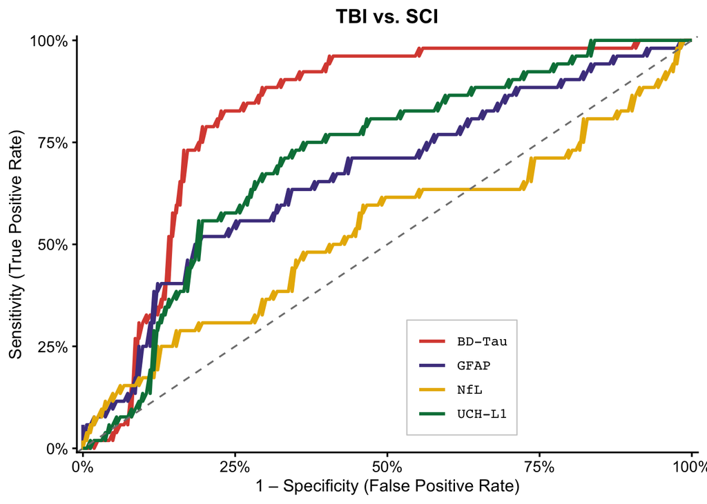

```r
    label_lines[bmkr] <- sprintf(
      "%s  AUC = %.2f (%.2f–%.2f)",
      biomarker_labels[[bmkr]], auc_val, ci_val[1], ci_val[3]
    )
  }

  all_curves <- bind_rows(curve_data)

  # Map display labels to colors
  color_map <- setNames(
    biomarker_colors[bmkrs],
    biomarker_labels[bmkrs]
  )

  p <- ggplot(all_curves, aes(x = fpr, y = tpr, color = Biomarker)) +
    geom_line(linewidth = 1.1) +
    geom_abline(slope = 1, intercept = 0,
                linetype = "dashed", color = "grey50", linewidth = 0.6) +
    scale_color_manual(
      values = color_map,
      labels = label_lines[bmkrs],   # AUC labels in legend
      name = NULL
    ) +
    scale_x_continuous(expand = c(0.01, 0), limits = c(0, 1),
                       labels = scales::percent_format(accuracy = 1)) +
    scale_y_continuous(expand = c(0.01, 0), limits = c(0, 1),
                       labels = scales::percent_format(accuracy = 1)) +
    labs(
      title = comp_name,
      x = "1 – Specificity (False Positive Rate)",
      y = "Sensitivity (True Positive Rate)"
    ) +
    theme_classic(base_size = 13) +
    theme(
      plot.title = element_text(face = "bold", size = 14, hjust = 0.5),
      legend.position = c(0.62, 0.18),
      legend.background = element_rect(fill = alpha("white", 0.85),
                                       color = "grey80", linewidth = 0.4),
      legend.text = element_text(size = 10, family = "mono"),
      legend.key.width = unit(1.6, "lines"),
      axis.text = element_text(size = 11),
      axis.title = element_text(size = 12)
    )

  plot_list[[comp_name]] <- p
}

plot_list$`TBI vs. SCI`
```

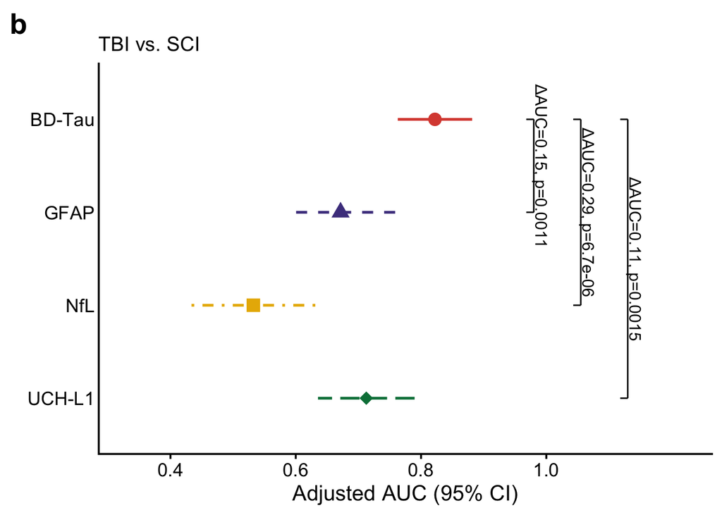

```r
biomarker_shapes <- c(
  "commercial_BDtau_conc" = 16,  # circle
  "GFAP_N4PD" = 17,  # triangle
  "NfL_N4PD" = 15,  # square
  "UCH_L1_N4PD" = 18   # diamond
)
biomarker_lty <- c(
  "commercial_BDtau_conc" = "solid",
  "GFAP_N4PD" = "dashed",
  "NfL_N4PD" = "dotdash",
  "UCH_L1_N4PD" = "longdash"
)

# bottom-to-top order so BD-Tau ends up on top
bm_order <- c("UCH_L1_N4PD", "NfL_N4PD", "GFAP_N4PD", "commercial_BDtau_conc")

# ---- data ----
forest_tbisci <- all_roc_results_forest %>%
  filter(Comparison == "TBI vs. SCI") %>%
  mutate(Biomarker = factor(Biomarker, levels = bm_order))

# numeric y position of each biomarker (discrete axis maps to 1..n)
ypos <- setNames(seq_along(bm_order), bm_order)

# ---- ΔAUC brackets (BD-Tau vs each comparator) ----
bdtau_auc <- forest_tbisci$AUC[forest_tbisci$Biomarker == "commercial_BDtau_conc"]

delong_tbisci <- all_delong_results %>% filter(Comparison == "TBI vs. SCI")

# p-value lookup: comparator biomarker -> DeLong p vs BD-Tau
delong_p <- setNames(delong_tbisci$P_value, delong_tbisci$Biomarker2)

# format to 2 significant figures (e.g. 0.0011, 6.7e-06, 0.0015)
fmt_p <- function(p) formatC(signif(p, 2), format = "g", digits = 2)

bracket_df <- forest_tbisci %>%
  filter(Biomarker != "commercial_BDtau_conc") %>%
  transmute(
    Biomarker = as.character(Biomarker),
    y_top = ypos["commercial_BDtau_conc"],
    y_bot = ypos[as.character(Biomarker)],
    dAUC  = bdtau_auc - AUC,
    label = sprintf("\u0394AUC=%.2f, p=%s", dAUC, fmt_p(delong_p[as.character(Biomarker)]))
  ) %>%
  # innermost bracket (shortest span, GFAP) leftmost; outermost (UCH-L1) rightmost
  arrange(desc(y_bot)) %>%
  mutate(xpos = 0.98 + (row_number() - 1) * 0.075)

tick <- 0.012
add_bracket <- function(d) {
  list(
    annotate("segment", x = d$xpos, xend = d$xpos, y = d$y_bot, yend = d$y_top, linewidth = 0.5),
    annotate("segment", x = d$xpos, xend = d$xpos - tick, y = d$y_top, yend = d$y_top, linewidth = 0.5),
    annotate("segment", x = d$xpos, xend = d$xpos - tick, y = d$y_bot, yend = d$y_bot, linewidth = 0.5),
    annotate("text", x = d$xpos + 0.012, y = (d$y_top + d$y_bot) / 2,
             label = d$label, angle = -90, size = 4)
  )
}
bracket_layers <- do.call(c, lapply(seq_len(nrow(bracket_df)),
                                    function(i) add_bracket(bracket_df[i, ])))

p <- ggplot(forest_tbisci, aes(x = AUC, y = Biomarker,
                               color = Biomarker, shape = Biomarker, linetype = Biomarker)) +
  geom_errorbarh(aes(xmin = CI_Lower, xmax = CI_Upper), height = 0, linewidth = 0.9) +
  geom_point(size = 4) +
  bracket_layers +
  scale_color_manual(values = biomarker_colors) +
  scale_shape_manual(values = biomarker_shapes) +
  scale_linetype_manual(values = biomarker_lty) +
  scale_y_discrete(labels = biomarker_labels) +
  scale_x_continuous(limits = c(0.33, 1.22), breaks = seq(0.4, 1.0, 0.2)) +
  labs(x = "Adjusted AUC (95% CI)", y = NULL, tag = "b", title = "TBI vs. SCI") +
  theme_classic(base_size = 14) +
  theme(
    legend.position = "none",
    plot.tag = element_text(face = "bold", size = 20),
    plot.title = element_text(size = 14, hjust = 0, margin = margin(b = 6)),
    axis.text.y = element_text(size = 13, color = "black"),
    axis.text.x = element_text(size = 13, color = "black"),
    axis.title.x = element_text(size = 15),
    axis.ticks.y = element_blank()
  )

print(p)
```

```r
# ============================================
# Serum Cohort: Longitudinal Spaghetti Plots with Control
# Panel A: Control vs. SCI vs. TBI (3-group)
# Panel B: Control vs. Subgroups (Moderate/Severe TBI + ASIA SCI)
# Note: Control excluded from mixed-effects models
# ============================================

library(lme4)
library(dplyr)
library(ggplot2)
library(patchwork)
library(data.table)

# ============================================
# PREPARE DATA - SERUM COHORT WITH CONTROL
# ============================================

# ASIA IDs for SCI subgroups
asia_a_ids <- sci_serum_demo_BL_cleaned[
  !is.na(sci_serum_demo_BL_cleaned$ASIA) &
    sci_serum_demo_BL_cleaned$ASIA == "A", ]$Subject.ID

asia_b_ids <- sci_serum_demo_BL_cleaned[
  !is.na(sci_serum_demo_BL_cleaned$ASIA) &
    sci_serum_demo_BL_cleaned$ASIA == "B", ]$Subject.ID

asia_cd_ids <- sci_serum_demo_BL_cleaned[
  !is.na(sci_serum_demo_BL_cleaned$ASIA) &
    sci_serum_demo_BL_cleaned$ASIA %in% c("C","D"), ]$Subject.ID

# Get intersection of variables
intersect_vars <- Reduce(intersect, list(
  names(cntr),
  names(sci_serum_demo),
  names(tbi_serum_demo)
))

serum_cleaned <- rbindlist(
  list(
    cntr %>% dplyr::select(all_of(intersect_vars)),
    sci_serum_demo %>% dplyr::select(all_of(intersect_vars)),
    tbi_serum_demo %>% dplyr::select(all_of(intersect_vars))
  ),
  use.names = TRUE,
  fill = FALSE
) %>%
  filter(Subject.ID %in% serum_baseline_cleaned$Subject.ID) %>%
  mutate(
    Cohort = factor(Cohort, levels = c("Control", "SCI", "Mild TBI", "Moderate TBI", "Severe TBI")),
    # 3-group classification (exclude Mild TBI)
    Cohort3 = factor(
      case_when(
        Cohort == "Control" ~ "Control",
        Cohort == "SCI" ~ "SCI",
        Cohort %in% c("Moderate TBI", "Severe TBI") ~ "TBI",
        TRUE ~ NA_character_
      ),
      levels = c("Control", "SCI", "TBI")
    ),
    # Subgroup classification
    Cohort_Subgroup = case_when(
      Cohort == "Control" ~ "Control",
      !is.na(Subject.ID) & Subject.ID %in% asia_a_ids ~ "A SCI",
      !is.na(Subject.ID) & Subject.ID %in% asia_b_ids ~ "B SCI",
      !is.na(Subject.ID) & Subject.ID %in% asia_cd_ids ~ "C/D SCI",
      Cohort == "Moderate TBI" ~ "Moderate TBI",
      Cohort == "Severe TBI" ~ "Severe TBI",
      TRUE ~ as.character(Cohort)
    ),
    Cohort_Subgroup = factor(Cohort_Subgroup,
                             levels = c("Control", "A SCI", "B SCI", "C/D SCI",
                                        "Moderate TBI", "Severe TBI")),
    # Set Control timepoint to 0
    serum_First_Digit_12Hr = case_when(
      Cohort == "Control" ~ 0,
      TRUE ~ serum_First_Digit_12Hr
    )
  ) %>%
  group_by(Subject.ID) %>%
  mutate(time_since_baseline =
           serum_First_Digit_12Hr -
           min(serum_First_Digit_12Hr, na.rm = TRUE)) %>%
  ungroup() %>%
  filter(!is.na(Cohort3) | !is.na(Cohort_Subgroup))  # Keep valid subjects

# Color palettes
color_3group <- c(
  "Control" = "black",
  "SCI" = "#07668d",
  "TBI" = "#813405"
)

color_subgroup <- c(
  "Control" = "black",
  "A SCI" = "#007382",
  "B SCI" = "#019787",
  "C/D SCI" = "#82e1cd",
  "Moderate TBI" = "#f9a03f",
  "Severe TBI" = "#d45113"
)

# ============================================
# PANEL A: Control vs. SCI vs. TBI (3-group)
# ============================================

# Filter to first 12 timepoints (0-144 hours)
dd_3group <- serum_cleaned %>%
  mutate(time_since_baseline = as.numeric(time_since_baseline)) %>%
  filter(time_since_baseline <= 12) %>%
  filter(!is.na(Cohort3))

# Prepare plot data
plot_data_3group <- dd_3group %>%
  filter(!is.na(time_since_baseline), !is.na(serum_BDTau)) %>%
  mutate(
    group = Cohort3,
    time_hours = as.numeric(as.character(time_since_baseline)) * 12,
    subject = as.factor(Subject.ID)
  )

# Summarize mean ± SE
summary_3group <- plot_data_3group %>%
  group_by(group, time_hours) %>%
  dplyr::summarise(
    n = dplyr::n(),
    mean_val = base::mean(serum_BDTau, na.rm = TRUE),
    sd_val = stats::sd(serum_BDTau, na.rm = TRUE),
    .groups = "drop"
  ) %>%
  mutate(se_val = sd_val / sqrt(n))

# Count unique subjects per group
group_counts_3group <- plot_data_3group %>%
  dplyr::select(Subject.ID, group) %>%
  distinct() %>%
  dplyr::count(group) %>%
  mutate(label = paste0(group, " (N=", n, ")"))

# Mixed-effects model for statistics - EXCLUDE CONTROL
plot_data_3group_no_control <- plot_data_3group %>%
  filter(group != "Control")

lmm_3group <- lmer(serum_log2_BDTau ~ group * time_hours + (1 | subject),
                   data = plot_data_3group_no_control)
anova_3group <- anova(lmm_3group)

cat("\n=== PANEL A: 3-GROUP MODEL (EXCLUDING CONTROL) ===\n")
```

```
##
## === PANEL A: 3-GROUP MODEL (EXCLUDING CONTROL) ===
```

```r
print(anova_3group)
```

```
## Type III Analysis of Variance Table with Satterthwaite's method
##                  Sum Sq Mean Sq NumDF   DenDF F value    Pr(>F)
## group            41.655  41.655     1  351.13 131.232 < 2.2e-16 ***
## time_hours       66.526  66.526     1 1838.53 209.588 < 2.2e-16 ***
## group:time_hours 16.600  16.600     1 1838.53  52.297 6.968e-13 ***
## ---
## Signif. codes:  0 '***' 0.001 '**' 0.01 '*' 0.05 '.' 0.1 ' ' 1
```

```r
cat("\n")
```

```r
# Per-timepoint statistics - EXCLUDE CONTROL
library(dplyr)
library(tidyr)

tp_pvals_3group <- plot_data_3group_no_control %>%
  filter(!is.na(time_hours), !is.na(group), !is.na(serum_log2_BDTau)) %>%
  group_by(time_hours) %>%
  group_modify(~{
    dat <- .x

    n_by_group <- dat %>% count(group, name = "n") %>%
      mutate(group = as.character(group))

    if (n_distinct(dat$group) < 2) {
      out <- tibble(p = NA_real_, test = "kruskal")
    } else {
      out <- tibble(
        p = kruskal.test(serum_log2_BDTau ~ group, data = dat)$p.value,
        test = "kruskal"
      )
    }

    out %>%
      bind_cols(
        n_by_group %>%
          pivot_wider(names_from = group, values_from = n, names_prefix = "n_")
      )
  }) %>%
  ungroup() %>%
  mutate(p_adj = p.adjust(p, method = "BH"))

# Create plot - NO STATISTICS
p_serum_3group <- ggplot(summary_3group, aes(x = time_hours, y = mean_val, color = group)) +
  geom_line(aes(group = group, linetype = group), linewidth = 0.8, alpha = 0.7) +
  geom_errorbar(aes(ymin = mean_val - se_val, ymax = mean_val + se_val),
                width = 2, linewidth = 0.6) +
  geom_point(aes(shape = group, size = group)) +
  scale_color_manual(
    values = color_3group
  ) +
  scale_size_manual(
    values = c("Control" = 3, "SCI" = 2.5, "TBI" = 2.5)
  ) +
  scale_shape_manual(
    values = c("Control" = 2, "SCI" = 16, "TBI" = 16)
  ) +
  scale_linetype_manual(
    values = c("Control" = "solid", "SCI" = "solid", "TBI" = "dashed")
  ) +
  guides(
    size = "none",
    shape = "none",
    linetype = "none"
  ) +
  labs(
    title = NULL, # "Serum BD-Tau: Control vs. SCI vs. TBI",
    x = "Hours Post-Injury",
    y = "Serum BD-Tau (pg/mL)",
    color = "Group",
    linetype = "Group"
  ) +
  scale_x_continuous(breaks = seq(0, 144, by = 24)) +
  theme_classic(base_size = 12) +
  theme(
    legend.position = "top",
    plot.title = element_text(face = "bold", size = 13)
  )

tp_annot <- tp_pvals_3group %>%
  mutate(
    p_star = case_when(
      p_adj < 1e-4 ~ "****",
      p_adj < 1e-3 ~ "***",
      p_adj < 1e-2 ~ "**",
      p_adj < 5e-2 ~ "*",
      TRUE ~ "ns"
    ),
    n_label = paste0("SCI n=", n_SCI, "\nTBI n=", n_TBI)
  )

y_star_pos <- summary_3group %>%
  group_by(time_hours) %>%
  summarise(y = max(mean_val + se_val, na.rm = TRUE), .groups = "drop")

tp_annot <- tp_annot %>%
  left_join(y_star_pos, by = "time_hours") %>%
  mutate(
    y_star = y + 0.08 * diff(range(summary_3group$mean_val, na.rm = TRUE))
  )

p_serum_3group_annot <- p_serum_3group +
  # FDR-adjusted p-value stars
  geom_text(
    data = tp_annot,
    aes(x = time_hours, y = y_star, label = p_star),
    inherit.aes = FALSE,
    size = 4,
    vjust = 0
  )

# ============================================
# PANEL B: Control vs. Subgroups
# ============================================

dd_subgroup <- serum_cleaned %>%
  mutate(time_since_baseline = as.numeric(time_since_baseline)) %>%
  filter(time_since_baseline <= 12) %>%
  filter(!is.na(Cohort_Subgroup))

# Prepare plot data
plot_data_subgroup <- dd_subgroup %>%
  filter(!is.na(time_since_baseline), !is.na(serum_BDTau)) %>%
  mutate(
    group = Cohort_Subgroup,
    time_hours = as.numeric(as.character(time_since_baseline)) * 12,
    subject = as.factor(Subject.ID)
  )

# Summarize mean ± SE
summary_subgroup <- plot_data_subgroup %>%
  group_by(group, time_hours) %>%
  summarise(
    n = dplyr::n(),
    mean_val = base::mean(serum_BDTau, na.rm = TRUE),
    sd_val = stats::sd(serum_BDTau, na.rm = TRUE),
    .groups = "drop"
  ) %>%
  mutate(se_val = sd_val / sqrt(n))

# Count unique subjects per group
group_counts_subgroup <- plot_data_subgroup %>%
  dplyr::select(Subject.ID, group) %>%
  distinct() %>%
  count(group) %>%
  mutate(label = paste0(group, " (N=", n, ")"))

# Mixed-effects model for statistics - EXCLUDE CONTROL
plot_data_subgroup_no_control <- plot_data_subgroup %>%
  filter(group != "Control")

lmm_subgroup <- lmer(serum_log2_BDTau ~ group * time_hours + (1 | subject),
                     data = plot_data_subgroup_no_control)
anova_subgroup <- anova(lmm_subgroup)

cat("\n=== PANEL B: SUBGROUP MODEL (EXCLUDING CONTROL) ===\n")
```

```
##
## === PANEL B: SUBGROUP MODEL (EXCLUDING CONTROL) ===
```

```r
print(anova_subgroup)
```

```
## Type III Analysis of Variance Table with Satterthwaite's method
##                  Sum Sq Mean Sq NumDF   DenDF F value    Pr(>F)
## group            43.204 10.8009     4  345.62  33.764 < 2.2e-16 ***
## time_hours       15.508 15.5082     1 1831.03  48.479 4.636e-12 ***
## group:time_hours 17.058  4.2644     4 1821.64  13.331 1.040e-10 ***
## ---
## Signif. codes:  0 '***' 0.001 '**' 0.01 '*' 0.05 '.' 0.1 ' ' 1
```

```r
cat("\n")
```

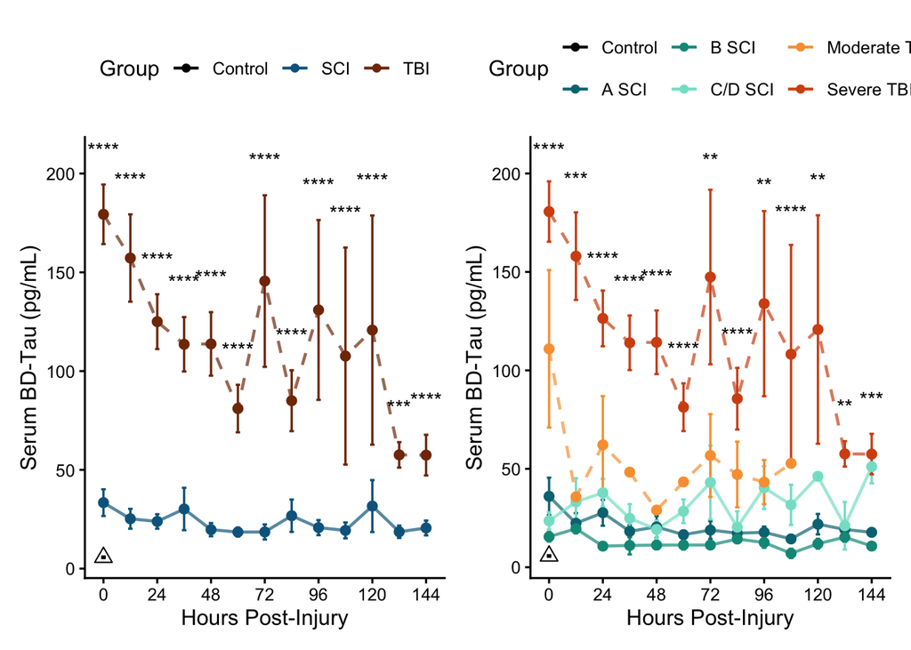

```r
# Per-timepoint statistics - EXCLUDE CONTROL
library(dplyr)
library(tidyr)

tp_pvals_subgroup <- plot_data_subgroup_no_control %>%
  filter(!is.na(time_hours), !is.na(group), !is.na(serum_log2_BDTau)) %>%
  group_by(time_hours) %>%
  group_modify(~{
    dat <- .x

    # n per group at this timepoint
    n_by_group <- dat %>%
      count(group, name = "n") %>%
      mutate(group = as.character(group)) %>%
      pivot_wider(names_from = group, values_from = n, names_prefix = "n_")

    # need >=2 groups present
    if (n_distinct(dat$group) < 2) {
      out <- tibble(p = NA_real_, test = "kruskal")
    } else {
      out <- tibble(
        p = kruskal.test(serum_log2_BDTau ~ group, data = dat)$p.value,
        test = "kruskal"
      )
    }

    bind_cols(out, n_by_group)
  }) %>%
  ungroup() %>%
  mutate(p_adj = p.adjust(p, method = "BH"))

library(dplyr)
library(tidyr)

tp_pvals_severe_vs_ASCI <- plot_data_subgroup_no_control %>%
  filter(
    group %in% c("Severe TBI", "A SCI"),
    !is.na(time_hours),
    !is.na(serum_log2_BDTau)
  ) %>%
  group_by(time_hours) %>%
  group_modify(~{
    dat <- .x

    n_severe <- sum(dat$group == "Severe TBI")
    n_asci   <- sum(dat$group == "A SCI")

    # need both groups present
    if (n_severe == 0 || n_asci == 0) {
      tibble(
        p = NA_real_,
        test = "wilcox",
        n_Severe_TBI = n_severe,
        n_A_SCI = n_asci
      )
    } else {
      tibble(
        p = wilcox.test(
          serum_log2_BDTau ~ group,
          data = dat,
          exact = FALSE
        )$p.value,
        test = "wilcox",
        n_Severe_TBI = n_severe,
        n_A_SCI = n_asci
      )
    }
  }) %>%
  ungroup() %>%
  mutate(p_adj = p.adjust(p, method = "BH"))

# Create plot - NO STATISTICS
p_serum_subgroup <- ggplot(summary_subgroup, aes(x = time_hours, y = mean_val, color = group)) +
  geom_line(aes(group = group, linetype = group), linewidth = 0.8, alpha = 0.7) +
  geom_errorbar(aes(ymin = mean_val - se_val, ymax = mean_val + se_val),
                width = 2, linewidth = 0.6) +
  geom_point(aes(size = group, shape = group)) +
  scale_color_manual(
    values = color_subgroup
  ) +
  scale_shape_manual(
    values = c("Control" = 2, "A SCI" = 16, "B SCI" = 16, "C/D SCI" = 16,
               "Moderate TBI" = 16, "Severe TBI" = 16)
  ) +
  scale_size_manual(
    values = c("Control" = 3, "A SCI" = 2.5, "B SCI" = 2.5, "C/D SCI" = 2.5,
               "Moderate TBI" = 2.5, "Severe TBI" = 2.5)
  ) +
  scale_linetype_manual(
    values = c("Control" = "solid",
               "A SCI" = "solid", "B SCI" = "solid", "C/D SCI" = "solid",
               "Moderate TBI" = "dashed", "Severe TBI" = "dashed")
  ) +
  labs(
    title = NULL, # "Serum BD-Tau: Control vs. Subgroups",
    x = "Hours Post-Injury",
    y = "Serum BD-Tau (pg/mL)",
    color = "Group",
    linetype = "Group"
  ) +
  guides(
    size = "none",
    shape = "none",
    linetype = "none"
  ) +
  scale_x_continuous(breaks = seq(0, 144, by = 24)) +
  theme_classic(base_size = 12) +
  theme(
    legend.position = "top",
    plot.title = element_text(face = "bold", size = 13)
  )

tp_annot <- tp_pvals_severe_vs_ASCI %>%
  mutate(
    p_star = case_when(
      p_adj < 1e-4 ~ "****",
      p_adj < 1e-3 ~ "***",
      p_adj < 1e-2 ~ "**",
      p_adj < 5e-2 ~ "*",
      TRUE ~ "ns"
    )
  )

y_star_pos <- summary_3group %>%
  group_by(time_hours) %>%
  summarise(y = max(mean_val + se_val, na.rm = TRUE), .groups = "drop")

tp_annot <- tp_annot %>%
  left_join(y_star_pos, by = "time_hours") %>%
  mutate(
    y_star = y + 0.08 * diff(range(summary_3group$mean_val, na.rm = TRUE))
  )

p_serum_subgroup_annot <- p_serum_subgroup +
  # FDR-adjusted p-value stars
  geom_text(
    data = tp_annot,
    aes(x = time_hours, y = y_star, label = p_star),
    inherit.aes = FALSE,
    size = 4,
    vjust = 0
  )

# ============================================
# COMBINE PLOTS - 2-PANEL LAYOUT
# ============================================

fig_serum_combined <- p_serum_3group_annot +
  ggtitle(NULL)+
  p_serum_subgroup_annot +
  ggtitle(NULL) +
  plot_layout(ncol = 2) +
  plot_annotation(
    # tag_levels = 'A',
    title = NULL,
    theme = theme(
      plot.tag = element_text(size = 14, face = "bold"),
      plot.title = element_text(size = 15, face = "bold", hjust = 0.5)
    )
  )

# Display
print(fig_serum_combined)
```

```r
library(writexl)

# Prepare ANOVA results as data frames
anova_3group_df <- as.data.frame(anova_3group) %>%
  tibble::rownames_to_column("Term") %>%
  mutate(Analysis = "Panel A: 3-group (SCI vs TBI, Control excluded)")

anova_subgroup_df <- as.data.frame(anova_subgroup) %>%
  tibble::rownames_to_column("Term") %>%
  mutate(Analysis = "Panel B: Subgroups (Control excluded)")

# Combine all statistics
all_statistics <- list(
  # Summary statistics (INCLUDING Control for display)
  "PanelA_3group_Summary" = summary_3group,
  "PanelB_Subgroup_Summary" = summary_subgroup,

  # Per-timepoint p-values (EXCLUDING Control)
  "PanelA_Timepoint_Pvals" = tp_pvals_3group %>%
    mutate(Note = "SCI vs TBI only, Control excluded"),
  "PanelB_Timepoint_Pvals" = tp_pvals_subgroup %>%
    mutate(Note = "Among subgroups only, Control excluded"),

  # Mixed-effects model ANOVA results (EXCLUDING Control)
  "PanelA_ANOVA" = anova_3group_df,
  "PanelB_ANOVA" = anova_subgroup_df,

  # Sample sizes
  "Sample_Sizes" = bind_rows(
    group_counts_3group %>% mutate(Panel = "A: 3-group"),
    group_counts_subgroup %>% mutate(Panel = "B: Subgroups")
  )
)
```

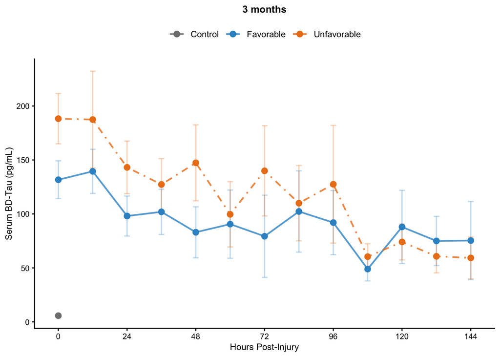

```r
## ============================================================
## Serum BD-Tau Longitudinal Trajectory: Favorable vs Unfavorable GOS (3 months)
##
## Compares serum BD-Tau trajectories (log2 scale) between subjects with
## Favorable vs Unfavorable outcome (GOS at 3 months), with Controls shown
## for visual reference only (excluded from statistical models).
##
## Inputs (expected in the calling environment / project data folder):
##   - tbi_serum_demo             : long-format serum data per subject/timepoint
##   - tbi_serum_demo_BL_cleaned  : subject IDs with valid baseline data
##   - cntr                       : control subject data
##
## Outputs:
##   - <results_path>/serum_3mo_GOS_pairwise_analysis.xlsx
##   - <figures_path>/serum_bdtau_by_GOS_fav_vs_unfav_3mo.pdf
## ============================================================

library(mgcv)
library(knitr)
library(kableExtra)
library(lme4)
library(lmerTest)
library(dplyr)
library(ggplot2)
library(cowplot)
library(tidyr)
library(purrr)
library(writexl)

outcome_col <- "GOS_03"
time_col <- "time_since_baseline"
y_col <- "mean_serum_BDTau"
log_y_col <- "mean_serum_log2_BDTau"

outcome_colors <- c(
  "Control" = "grey50",
  "Favorable" = "#3594cc",
  "Unfavorable" = "#ea801c"
)

outcome_linetypes <- c(
  "Control" = "solid",
  "Favorable" = "solid",
  "Unfavorable" = "dotdash"
)

# ------------------------------------------------------------
# Prepare data
# ------------------------------------------------------------

serum_cleaned <- tbi_serum_demo %>%
  filter(Subject.ID %in% tbi_serum_demo_BL_cleaned$Subject.ID) %>%
  mutate(serum_First_Digit_24Hr = trunc(serum_First_Digit_12Hr / 2)) %>%
  group_by(Subject.ID) %>%
  mutate(time_since_baseline = serum_First_Digit_12Hr - min(serum_First_Digit_12Hr, na.rm = TRUE)) %>%
  ungroup() %>%
  filter(!is.na(baseline_time))

# Add control group (treated as time 0 for plotting reference)
cntr_ref <- cntr %>%
  mutate(time_since_baseline = 0, GOS_03 = "Control")

intersect_vars <- intersect(colnames(cntr_ref), colnames(serum_cleaned))

dd <- bind_rows(
  serum_cleaned %>% dplyr::select(all_of(intersect_vars)) %>% filter(time_since_baseline <= 12),
  cntr_ref %>% dplyr::select(all_of(intersect_vars))
)

stopifnot(all(c("Subject.ID", time_col, y_col, log_y_col, outcome_col) %in% names(dd)))

plot_data <- data.frame(
  Subject.ID = dd$Subject.ID,
  group_raw = dplyr::recode(dd[[outcome_col]], "Dead" = "Deceased"),
  time = as.numeric(dd[[time_col]]),
  time_hours = as.numeric(dd[[time_col]]) * 12,
  y_raw = dd[[y_col]],
  y_log2 = dd[[log_y_col]],
  stringsAsFactors = FALSE
) %>%
  filter(
    !is.na(group_raw), group_raw %in% c("Control", "Favorable", "Unfavorable"),
    !is.na(time), !is.na(y_raw), !is.na(y_log2)
  ) %>%
  mutate(
    group = factor(group_raw, levels = c("Control", "Favorable", "Unfavorable")),
    subject = factor(Subject.ID)
  )

# Mixed effects model (Favorable vs Unfavorable only; Control excluded)

plot_data_model <- plot_data %>%
  filter(group != "Control") %>%
  mutate(group = factor(group, levels = c("Favorable", "Unfavorable")))

interaction_p <- NA_real_

if (nrow(plot_data_model) >= 10 && dplyr::n_distinct(plot_data_model$group) >= 2) {

  lmm <- lmerTest::lmer(y_log2 ~ group * time + (1 | subject), data = plot_data_model)
  coef_table <- summary(lmm)$coefficients

  if ("groupUnfavorable:time" %in% rownames(coef_table)) {
    interaction_p <- coef_table["groupUnfavorable:time", "Pr(>|t|)"]
  }

  message("Group x time interaction p = ", format.pval(interaction_p, digits = 4))
}

n_favorable   <- sum(plot_data_model$group == "Favorable", na.rm = TRUE)
n_unfavorable <- sum(plot_data_model$group == "Unfavorable", na.rm = TRUE)

# Per-timepoint pairwise comparisons (Wilcoxon on log2 scale, BH-adjusted)

all_groups <- c("Control", "Favorable", "Unfavorable")
pairwise_comparisons <- combn(all_groups, 2, simplify = FALSE)
unique_times <- sort(unique(plot_data$time_hours))

pairwise_results <- map_dfr(unique_times, function(time_pt) {

  time_data <- plot_data %>% filter(time_hours == time_pt)

  map_dfr(pairwise_comparisons, function(pair) {

    data1 <- time_data$y_log2[time_data$group == pair[1]]
    data2 <- time_data$y_log2[time_data$group == pair[2]]
    n1 <- length(data1); n2 <- length(data2)

    if (n1 >= 2 && n2 >= 2) {
      test_result <- try(wilcox.test(data1, data2, exact = FALSE), silent = TRUE)
      p_val <- if (inherits(test_result, "try-error")) NA_real_ else test_result$p.value
      test_stat <- if (inherits(test_result, "try-error")) NA_real_ else unname(test_result$statistic)
    } else {
      p_val <- NA_real_
      test_stat <- NA_real_
    }

    tibble(
      time_hours = time_pt,
      group1 = pair[1], group2 = pair[2],
      n1 = n1, n2 = n2,
      test_statistic = test_stat,
      p_raw = p_val,
      comparison = paste0(pair[1], " vs ", pair[2])
    )
  })
}) %>%
  group_by(group1, group2) %>%
  mutate(
    p_adj = p.adjust(p_raw, method = "BH"),
    sig_adj = case_when(
      p_adj < 0.001 ~ "***",
      p_adj < 0.01  ~ "**",
      p_adj < 0.05  ~ "*",
      TRUE ~ "ns"
    )
  ) %>%
  ungroup()

# Save statistical results

interaction_summary <- tibble(
  GOS_Timepoint = "3 months",
  N_Favorable = n_favorable,
  N_Unfavorable = n_unfavorable,
  Interaction_FavVsUnfav_p = interaction_p
)

# Visualization

summary_df <- plot_data %>%
  group_by(group, time_hours) %>%
  dplyr::summarise(
    n = n(),
    mean_val = mean(y_raw, na.rm = TRUE),
    se_val = sd(y_raw, na.rm = TRUE) / sqrt(n),
    .groups = "drop"
  )

sig_markers <- pairwise_results %>%
  filter(group1 == "Favorable", group2 == "Unfavorable", sig_adj != "ns") %>%
  select(time_hours, sig_adj)

y_star <- max(summary_df$mean_val + summary_df$se_val, na.rm = TRUE) * 1.10

serum_plot <- ggplot(summary_df, aes(x = time_hours, y = mean_val, color = group)) +
  geom_line(aes(group = group, linetype = group), linewidth = 0.8, alpha = 0.8) +
  geom_errorbar(aes(ymin = mean_val - se_val, ymax = mean_val + se_val),
                width = 2, linewidth = 0.6, alpha = 0.3) +
  geom_point(size = 2.5) +
  scale_color_manual(values = outcome_colors, name = NULL) +
  scale_linetype_manual(values = outcome_linetypes, guide = "none") +
  geom_text(
    data = sig_markers,
    aes(x = time_hours, y = y_star, label = sig_adj),
    inherit.aes = FALSE, size = 5, fontface = "bold", color = "black"
  ) +
  labs(title = "3 months", x = "Hours Post-Injury", y = "Serum BD-Tau (pg/mL)") +
  scale_x_continuous(breaks = seq(0, 144, by = 24)) +
  theme_classic(base_size = 11) +
  theme(
    legend.position = "top",
    plot.title = element_text(size = 10, face = "bold", hjust = 0.5),
    axis.title = element_text(size = 9),
    axis.text = element_text(size = 8)
  )

print(serum_plot)
```